[figure not shown]

# How to Estimate Vehicle Speed with Computer Vision

## Accompanying Materials

We recommend that you follow along in this notebook while watching the YouTube [tutorial](https://youtu.be/uWP6UjDeZvY) on how to estimate vehicle speed with computer vision. You can also find the code below in Python script form as one of the [supervision/examples](https://github.com/roboflow/supervision/tree/develop/examples).

[figure not shown]

## Pro Tip: Use GPU Acceleration

If you are running this notebook in Google Colab, navigate to `Edit` -> `Notebook settings` -> `Hardware accelerator`, set it to `GPU`, and then click `Save`. This will ensure your notebook uses a GPU, which will significantly speed up model training times.

## Steps in this Tutorial

In this tutorial, we are going to cover:

- Before you start
- Install
- Imports
- Download Data
- Configuration
- Source and Target ROIs
- Transform Perspective
- Process Video

## Before you start

Let's make sure that we have access to GPU. We can use `nvidia-smi` command to do that. In case of any problems navigate to `Edit` -> `Notebook settings` -> `Hardware accelerator`, set it to `GPU`, and then click `Save`.

```python
!nvidia-smi
```

```
Mon May 25 14:05:21 2026
+-----------------------------------------------------------------------------------------+
| NVIDIA-SMI 580.82.07              Driver Version: 580.82.07      CUDA Version: 13.0     |
+-----------------------------------------+------------------------+----------------------+
| GPU  Name                 Persistence-M | Bus-Id          Disp.A | Volatile Uncorr. ECC |
| Fan  Temp   Perf          Pwr:Usage/Cap |           Memory-Usage | GPU-Util  Compute M. |
|                                         |                        |               MIG M. |
|=========================================+========================+======================|
|   0  Tesla T4                       Off |   00000000:00:04.0 Off |                    0 |
| N/A   71C    P0             30W /   70W |    1001MiB /  15360MiB |      0%      Default |
|                                         |                        |                  N/A |
+-----------------------------------------+------------------------+----------------------+

+-----------------------------------------------------------------------------------------+
| Processes:                                                                              |
|  GPU   GI   CI              PID   Type   Process name                        GPU Memory |
|        ID   ID                                                               Usage      |
|=========================================================================================|
|    0   N/A  N/A            1067      C   /usr/bin/python3                        998MiB |
+-----------------------------------------------------------------------------------------+
```

## Install

```python
!pip install -q supervision "ultralytics<=8.3.40"
```

## Imports

```python
# prevent ultralytics from tracking your activity
!yolo settings sync=False
```

```
JSONDict("/root/.config/Ultralytics/settings.json"):
{
  "settings_version": "0.0.6",
  "datasets_dir": "/content/datasets",
  "weights_dir": "weights",
  "runs_dir": "runs",
  "uuid": "569f3ba64b326db489132663f79cd37279811de477381b83ac131e6cdd129cbb",
  "sync": false,
  "api_key": "",
  "openai_api_key": "",
  "clearml": true,
  "comet": true,
  "dvc": true,
  "hub": true,
  "mlflow": true,
  "neptune": true,
  "raytune": true,
  "tensorboard": true,
  "wandb": false,
  "vscode_msg": true
}
💡 Learn more about Ultralytics Settings at https://docs.ultralytics.com/quickstart/#ultralytics-settings
```

```python
import cv2

import numpy as np
import supervision as sv

from tqdm import tqdm
from ultralytics import YOLO
from supervision.assets import VideoAssets, download_assets
from collections import defaultdict, deque
```

## Download Data

**NOTE:** In this notebook we will use one of the Supervision Assets videos. [Here](https://supervision.roboflow.com/assets) you can learn more about it.

```python
download_assets(VideoAssets.VEHICLES)
```

```
[2026-05-25 14:05:30] [INFO] supervision.assets.downloader - vehicles.mp4 asset download complete.
```

```
'vehicles.mp4'
```

## Configuration

```python
SOURCE_VIDEO_PATH = "vehicles.mp4"
TARGET_VIDEO_PATH = "vehicles-result.mp4"
CONFIDENCE_THRESHOLD = 0.3
IOU_THRESHOLD = 0.5
MODEL_NAME = "yolov8x.pt"
MODEL_RESOLUTION = 1280
```

## Source and Target ROIs

[figure not shown]

```python
SOURCE = np.array([
    [1252, 787],
    [2298, 803],
    [5039, 2159],
    [-550, 2159]
])

TARGET_WIDTH = 25
TARGET_HEIGHT = 250

TARGET = np.array([
    [0, 0],
    [TARGET_WIDTH - 1, 0],
    [TARGET_WIDTH - 1, TARGET_HEIGHT - 1],
    [0, TARGET_HEIGHT - 1],
])
```

```python
frame_generator = sv.get_video_frames_generator(source_path=SOURCE_VIDEO_PATH)
frame_iterator = iter(frame_generator)
frame = next(frame_iterator)
```

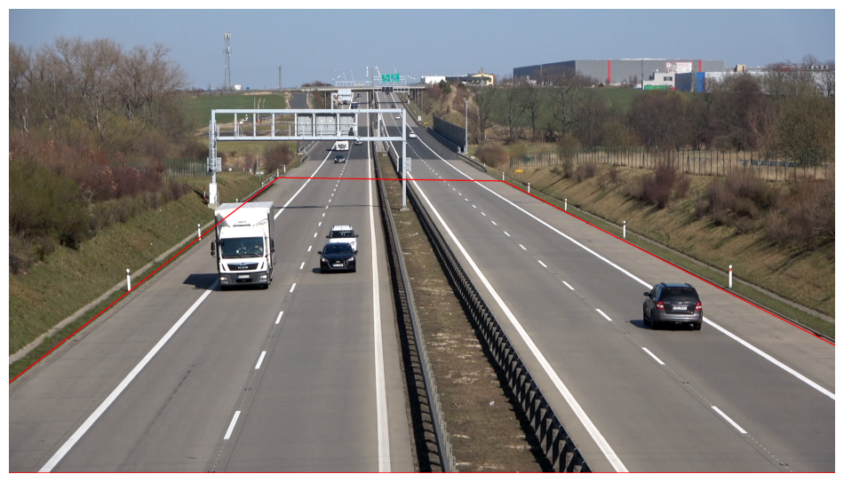

```python
annotated_frame = frame.copy()
annotated_frame = sv.draw_polygon(scene=annotated_frame, polygon=SOURCE, color=sv.Color.RED, thickness=4)
sv.plot_image(annotated_frame)
```

## Transform Perspective

```python
class ViewTransformer:

    def __init__(self, source: np.ndarray, target: np.ndarray) -> None:
        source = source.astype(np.float32)
        target = target.astype(np.float32)
        self.m = cv2.getPerspectiveTransform(source, target)

    def transform_points(self, points: np.ndarray) -> np.ndarray:
        if points.size == 0:
            return points

        reshaped_points = points.reshape(-1, 1, 2).astype(np.float32)
        transformed_points = cv2.perspectiveTransform(reshaped_points, self.m)
        return transformed_points.reshape(-1, 2)
```

```python
view_transformer = ViewTransformer(source=SOURCE, target=TARGET)
```

## Process Video

**NOTE:** In this tutorial we use Supervision Annotators. [Here](https://supervision.roboflow.com/annotators) you can learn more about it.

```python
model = YOLO(MODEL_NAME)

video_info = sv.VideoInfo.from_video_path(video_path=SOURCE_VIDEO_PATH)
frame_generator = sv.get_video_frames_generator(source_path=SOURCE_VIDEO_PATH)

# tracer initiation
byte_track = sv.ByteTrack(
    frame_rate=video_info.fps
)

# annotators configuration
thickness = sv.calculate_optimal_line_thickness(
    resolution_wh=video_info.resolution_wh
)

text_scale = sv.calculate_optimal_text_scale(
    resolution_wh=video_info.resolution_wh
)
##thickness = sv.calculate_dynamic_line_thickness(
    #resolution_wh=video_info.resolution_wh
#)
#text_scale = sv.calculate_dynamic_text_scale(
  #  resolution_wh=video_info.resolution_wh
#)
bounding_box_annotator = sv.BoxAnnotator(
    thickness=thickness
)
label_annotator = sv.LabelAnnotator(
    text_scale=text_scale,
    text_thickness=thickness,
    text_position=sv.Position.BOTTOM_CENTER
)
trace_annotator = sv.TraceAnnotator(
    thickness=thickness,
    trace_length=video_info.fps * 2,
    position=sv.Position.BOTTOM_CENTER
)

polygon_zone = sv.PolygonZone(
    polygon=SOURCE,
)

#coordinates = defaultdict(lambda: deque(maxlen=video_info.fps))
fps_int = int(round(video_info.fps))
coordinates = defaultdict(lambda: deque(maxlen=fps_int))
frame_idx = 0

# open target video
with sv.VideoSink(TARGET_VIDEO_PATH, video_info) as sink:


    # loop over source video frame
    for frame in tqdm(frame_generator, total=video_info.total_frames):
        frame_idx += 1
        result = model(frame, imgsz=MODEL_RESOLUTION, verbose=False)[0]
        detections = sv.Detections.from_ultralytics(result)

        # filter out detections by class and confidence
        detections = detections[detections.confidence > CONFIDENCE_THRESHOLD]
        detections = detections[detections.class_id != 0]

        # filter out detections outside the zone
        detections = detections[polygon_zone.trigger(detections)]

        # refine detections using non-max suppression
        detections = detections.with_nms(IOU_THRESHOLD)

        # pass detection through the tracker
        detections = byte_track.update_with_detections(detections=detections)

        points = detections.get_anchors_coordinates(
            anchor=sv.Position.BOTTOM_CENTER
        )

        # calculate the detections position inside the target RoI
        points = view_transformer.transform_points(points=points).astype(int)

        # store detections position
        for tracker_id, [_, y] in zip(detections.tracker_id, points):
            coordinates[tracker_id].append(y)

        # format labels
        labels = []

        for tracker_id in detections.tracker_id:
            if len(coordinates[tracker_id]) < video_info.fps / 2:
                labels.append(f"#{tracker_id}")
                speed = None
            else:
                # calculate speed
                coordinate_start = coordinates[tracker_id][-1]
                coordinate_end = coordinates[tracker_id][0]
                distance = abs(coordinate_start - coordinate_end)
                time = len(coordinates[tracker_id]) / video_info.fps
                speed = distance / time * 3.6
                labels.append(f"#{tracker_id} {int(speed)} km/h")
                #print(f"Vehicle ID: {tracker_id}, Speed: {int(speed)} km/h")
                if speed is not None:
                  print(f"Frame {frame_idx}, Vehicle ID: {tracker_id}, Speed: {int(speed)} km/h")


        # annotate frame
        annotated_frame = frame.copy()
        annotated_frame = trace_annotator.annotate(
            scene=annotated_frame, detections=detections
        )
        annotated_frame = bounding_box_annotator.annotate(
            scene=annotated_frame, detections=detections
        )
        annotated_frame = label_annotator.annotate(
            scene=annotated_frame, detections=detections, labels=labels
        )

        # add frame to target video
        sink.write_frame(annotated_frame)
```

```
Frame 13, Vehicle ID: 1, Speed: 76 km/h
Frame 13, Vehicle ID: 2, Speed: 124 km/h
Frame 13, Vehicle ID: 4, Speed: 152 km/h
Frame 13, Vehicle ID: 3, Speed: 124 km/h
```

```
Frame 14, Vehicle ID: 1, Speed: 77 km/h
Frame 14, Vehicle ID: 2, Speed: 122 km/h
Frame 14, Vehicle ID: 3, Speed: 122 km/h
Frame 14, Vehicle ID: 4, Speed: 154 km/h
```

```
Frame 15, Vehicle ID: 1, Speed: 78 km/h
Frame 15, Vehicle ID: 2, Speed: 126 km/h
Frame 15, Vehicle ID: 3, Speed: 126 km/h
Frame 15, Vehicle ID: 4, Speed: 156 km/h
```

```
Frame 16, Vehicle ID: 1, Speed: 78 km/h
Frame 16, Vehicle ID: 2, Speed: 123 km/h
Frame 16, Vehicle ID: 4, Speed: 157 km/h
Frame 16, Vehicle ID: 3, Speed: 123 km/h
```

```
Frame 17, Vehicle ID: 1, Speed: 79 km/h
Frame 17, Vehicle ID: 2, Speed: 127 km/h
Frame 17, Vehicle ID: 4, Speed: 153 km/h
Frame 17, Vehicle ID: 3, Speed: 127 km/h
```

```
Frame 18, Vehicle ID: 1, Speed: 80 km/h
Frame 18, Vehicle ID: 2, Speed: 125 km/h
Frame 18, Vehicle ID: 4, Speed: 155 km/h
Frame 18, Vehicle ID: 3, Speed: 125 km/h
```

```
Frame 19, Vehicle ID: 1, Speed: 80 km/h
Frame 19, Vehicle ID: 2, Speed: 123 km/h
Frame 19, Vehicle ID: 3, Speed: 127 km/h
Frame 19, Vehicle ID: 4, Speed: 156 km/h
```

```
Frame 20, Vehicle ID: 1, Speed: 81 km/h
Frame 20, Vehicle ID: 3, Speed: 126 km/h
Frame 20, Vehicle ID: 2, Speed: 126 km/h
Frame 20, Vehicle ID: 4, Speed: 153 km/h
```

```
Frame 21, Vehicle ID: 1, Speed: 81 km/h
Frame 21, Vehicle ID: 2, Speed: 124 km/h
Frame 21, Vehicle ID: 3, Speed: 128 km/h
Frame 21, Vehicle ID: 4, Speed: 154 km/h
```

```
Frame 22, Vehicle ID: 1, Speed: 81 km/h
Frame 22, Vehicle ID: 2, Speed: 126 km/h
Frame 22, Vehicle ID: 4, Speed: 155 km/h
Frame 22, Vehicle ID: 3, Speed: 126 km/h
```

```
Frame 23, Vehicle ID: 1, Speed: 82 km/h
Frame 23, Vehicle ID: 3, Speed: 129 km/h
Frame 23, Vehicle ID: 2, Speed: 125 km/h
Frame 23, Vehicle ID: 4, Speed: 152 km/h
```

```
Frame 24, Vehicle ID: 1, Speed: 82 km/h
Frame 24, Vehicle ID: 2, Speed: 127 km/h
Frame 24, Vehicle ID: 3, Speed: 127 km/h
Frame 24, Vehicle ID: 4, Speed: 153 km/h
```

```
Frame 25, Vehicle ID: 1, Speed: 79 km/h
Frame 25, Vehicle ID: 2, Speed: 126 km/h
Frame 25, Vehicle ID: 4, Speed: 151 km/h
Frame 25, Vehicle ID: 3, Speed: 126 km/h
```

```
Frame 26, Vehicle ID: 1, Speed: 82 km/h
Frame 26, Vehicle ID: 2, Speed: 122 km/h
Frame 26, Vehicle ID: 3, Speed: 126 km/h
Frame 26, Vehicle ID: 4, Speed: 147 km/h
```

```
Frame 27, Vehicle ID: 2, Speed: 126 km/h
Frame 27, Vehicle ID: 1, Speed: 82 km/h
Frame 27, Vehicle ID: 3, Speed: 129 km/h
Frame 27, Vehicle ID: 4, Speed: 151 km/h
```

```
Frame 28, Vehicle ID: 1, Speed: 79 km/h
Frame 28, Vehicle ID: 2, Speed: 122 km/h
Frame 28, Vehicle ID: 4, Speed: 144 km/h
Frame 28, Vehicle ID: 3, Speed: 126 km/h
```

```
Frame 29, Vehicle ID: 1, Speed: 79 km/h
Frame 29, Vehicle ID: 2, Speed: 126 km/h
Frame 29, Vehicle ID: 4, Speed: 147 km/h
Frame 29, Vehicle ID: 3, Speed: 129 km/h
```

```
Frame 30, Vehicle ID: 1, Speed: 79 km/h
Frame 30, Vehicle ID: 3, Speed: 126 km/h
Frame 30, Vehicle ID: 2, Speed: 122 km/h
Frame 30, Vehicle ID: 4, Speed: 144 km/h
```

```
Frame 31, Vehicle ID: 1, Speed: 79 km/h
Frame 31, Vehicle ID: 3, Speed: 129 km/h
Frame 31, Vehicle ID: 4, Speed: 140 km/h
Frame 31, Vehicle ID: 2, Speed: 126 km/h
```

```
Frame 32, Vehicle ID: 1, Speed: 79 km/h
Frame 32, Vehicle ID: 4, Speed: 140 km/h
Frame 32, Vehicle ID: 3, Speed: 126 km/h
Frame 32, Vehicle ID: 2, Speed: 126 km/h
```

```
Frame 33, Vehicle ID: 1, Speed: 79 km/h
Frame 33, Vehicle ID: 2, Speed: 126 km/h
Frame 33, Vehicle ID: 4, Speed: 136 km/h
Frame 33, Vehicle ID: 3, Speed: 126 km/h
```

```
Frame 34, Vehicle ID: 1, Speed: 82 km/h
Frame 34, Vehicle ID: 4, Speed: 133 km/h
Frame 34, Vehicle ID: 3, Speed: 126 km/h
Frame 34, Vehicle ID: 2, Speed: 126 km/h
```

```
Frame 35, Vehicle ID: 1, Speed: 82 km/h
Frame 35, Vehicle ID: 4, Speed: 133 km/h
Frame 35, Vehicle ID: 2, Speed: 126 km/h
Frame 35, Vehicle ID: 3, Speed: 129 km/h
```

```
Frame 36, Vehicle ID: 1, Speed: 82 km/h
Frame 36, Vehicle ID: 3, Speed: 126 km/h
Frame 36, Vehicle ID: 4, Speed: 136 km/h
Frame 36, Vehicle ID: 2, Speed: 126 km/h
```

```
Frame 37, Vehicle ID: 1, Speed: 82 km/h
Frame 37, Vehicle ID: 4, Speed: 136 km/h
Frame 37, Vehicle ID: 3, Speed: 129 km/h
Frame 37, Vehicle ID: 2, Speed: 122 km/h
```

```
Frame 38, Vehicle ID: 1, Speed: 82 km/h
Frame 38, Vehicle ID: 3, Speed: 129 km/h
Frame 38, Vehicle ID: 4, Speed: 136 km/h
Frame 38, Vehicle ID: 2, Speed: 126 km/h
```

```
Frame 39, Vehicle ID: 1, Speed: 82 km/h
Frame 39, Vehicle ID: 3, Speed: 129 km/h
Frame 39, Vehicle ID: 4, Speed: 133 km/h
Frame 39, Vehicle ID: 2, Speed: 122 km/h
```

```
Frame 40, Vehicle ID: 1, Speed: 82 km/h
Frame 40, Vehicle ID: 4, Speed: 133 km/h
Frame 40, Vehicle ID: 3, Speed: 129 km/h
Frame 40, Vehicle ID: 2, Speed: 126 km/h
```

```
Frame 41, Vehicle ID: 1, Speed: 82 km/h
Frame 41, Vehicle ID: 4, Speed: 133 km/h
Frame 41, Vehicle ID: 3, Speed: 126 km/h
Frame 41, Vehicle ID: 2, Speed: 122 km/h
```

```
Frame 42, Vehicle ID: 1, Speed: 82 km/h
Frame 42, Vehicle ID: 3, Speed: 129 km/h
Frame 42, Vehicle ID: 4, Speed: 133 km/h
Frame 42, Vehicle ID: 2, Speed: 126 km/h
```

```
Frame 43, Vehicle ID: 1, Speed: 79 km/h
Frame 43, Vehicle ID: 4, Speed: 133 km/h
Frame 43, Vehicle ID: 3, Speed: 129 km/h
Frame 43, Vehicle ID: 2, Speed: 126 km/h
```

```
Frame 44, Vehicle ID: 1, Speed: 79 km/h
Frame 44, Vehicle ID: 3, Speed: 129 km/h
Frame 44, Vehicle ID: 4, Speed: 133 km/h
Frame 44, Vehicle ID: 2, Speed: 126 km/h
```

```
Frame 45, Vehicle ID: 1, Speed: 82 km/h
Frame 45, Vehicle ID: 3, Speed: 129 km/h
Frame 45, Vehicle ID: 4, Speed: 133 km/h
Frame 45, Vehicle ID: 2, Speed: 126 km/h
```

```
Frame 46, Vehicle ID: 1, Speed: 79 km/h
Frame 46, Vehicle ID: 4, Speed: 129 km/h
Frame 46, Vehicle ID: 3, Speed: 129 km/h
Frame 46, Vehicle ID: 2, Speed: 122 km/h
```

```
Frame 47, Vehicle ID: 1, Speed: 79 km/h
Frame 47, Vehicle ID: 3, Speed: 129 km/h
Frame 47, Vehicle ID: 4, Speed: 133 km/h
Frame 47, Vehicle ID: 2, Speed: 126 km/h
```

```
Frame 48, Vehicle ID: 1, Speed: 79 km/h
Frame 48, Vehicle ID: 3, Speed: 129 km/h
Frame 48, Vehicle ID: 4, Speed: 133 km/h
Frame 48, Vehicle ID: 2, Speed: 122 km/h
```

```
Frame 49, Vehicle ID: 1, Speed: 82 km/h
Frame 49, Vehicle ID: 3, Speed: 126 km/h
Frame 49, Vehicle ID: 4, Speed: 133 km/h
Frame 49, Vehicle ID: 2, Speed: 126 km/h
```

```
Frame 50, Vehicle ID: 1, Speed: 79 km/h
Frame 50, Vehicle ID: 4, Speed: 133 km/h
Frame 50, Vehicle ID: 3, Speed: 118 km/h
Frame 50, Vehicle ID: 2, Speed: 126 km/h
```

```
Frame 51, Vehicle ID: 1, Speed: 79 km/h
Frame 51, Vehicle ID: 4, Speed: 129 km/h
Frame 51, Vehicle ID: 3, Speed: 111 km/h
Frame 51, Vehicle ID: 2, Speed: 126 km/h
```

```
Frame 52, Vehicle ID: 1, Speed: 82 km/h
Frame 52, Vehicle ID: 4, Speed: 133 km/h
Frame 52, Vehicle ID: 3, Speed: 108 km/h
Frame 52, Vehicle ID: 2, Speed: 126 km/h
```

```
Frame 53, Vehicle ID: 1, Speed: 82 km/h
Frame 53, Vehicle ID: 4, Speed: 129 km/h
Frame 53, Vehicle ID: 2, Speed: 122 km/h
Frame 53, Vehicle ID: 3, Speed: 100 km/h
```

```
Frame 54, Vehicle ID: 1, Speed: 82 km/h
Frame 54, Vehicle ID: 4, Speed: 133 km/h
Frame 54, Vehicle ID: 2, Speed: 126 km/h
Frame 54, Vehicle ID: 3, Speed: 97 km/h
```

```
Frame 55, Vehicle ID: 1, Speed: 82 km/h
Frame 55, Vehicle ID: 4, Speed: 136 km/h
Frame 55, Vehicle ID: 2, Speed: 122 km/h
Frame 55, Vehicle ID: 3, Speed: 90 km/h
```

```
Frame 56, Vehicle ID: 1, Speed: 82 km/h
Frame 56, Vehicle ID: 4, Speed: 136 km/h
Frame 56, Vehicle ID: 5, Speed: 193 km/h
Frame 56, Vehicle ID: 2, Speed: 122 km/h
```

```
Frame 57, Vehicle ID: 4, Speed: 133 km/h
Frame 57, Vehicle ID: 1, Speed: 82 km/h
Frame 57, Vehicle ID: 5, Speed: 186 km/h
Frame 57, Vehicle ID: 2, Speed: 122 km/h
```

```
Frame 58, Vehicle ID: 1, Speed: 82 km/h
Frame 58, Vehicle ID: 4, Speed: 129 km/h
Frame 58, Vehicle ID: 5, Speed: 186 km/h
Frame 58, Vehicle ID: 2, Speed: 122 km/h
```

```
Frame 59, Vehicle ID: 1, Speed: 82 km/h
Frame 59, Vehicle ID: 4, Speed: 122 km/h
Frame 59, Vehicle ID: 5, Speed: 180 km/h
Frame 59, Vehicle ID: 2, Speed: 122 km/h
```

```
Frame 60, Vehicle ID: 1, Speed: 82 km/h
Frame 60, Vehicle ID: 4, Speed: 115 km/h
Frame 60, Vehicle ID: 5, Speed: 174 km/h
Frame 60, Vehicle ID: 2, Speed: 122 km/h
```

```
Frame 61, Vehicle ID: 1, Speed: 79 km/h
Frame 61, Vehicle ID: 4, Speed: 111 km/h
Frame 61, Vehicle ID: 5, Speed: 175 km/h
Frame 61, Vehicle ID: 2, Speed: 122 km/h
```

```
Frame 62, Vehicle ID: 1, Speed: 79 km/h
Frame 62, Vehicle ID: 5, Speed: 170 km/h
Frame 62, Vehicle ID: 2, Speed: 122 km/h
Frame 62, Vehicle ID: 4, Speed: 104 km/h
```

```
Frame 63, Vehicle ID: 1, Speed: 75 km/h
Frame 63, Vehicle ID: 5, Speed: 171 km/h
Frame 63, Vehicle ID: 4, Speed: 100 km/h
Frame 63, Vehicle ID: 2, Speed: 122 km/h
```

```
Frame 64, Vehicle ID: 1, Speed: 72 km/h
Frame 64, Vehicle ID: 5, Speed: 167 km/h
Frame 64, Vehicle ID: 2, Speed: 122 km/h
```

```
Frame 65, Vehicle ID: 1, Speed: 68 km/h
Frame 65, Vehicle ID: 5, Speed: 163 km/h
Frame 65, Vehicle ID: 2, Speed: 122 km/h
```

```
Frame 66, Vehicle ID: 1, Speed: 64 km/h
Frame 66, Vehicle ID: 5, Speed: 164 km/h
Frame 66, Vehicle ID: 2, Speed: 118 km/h
```

```
Frame 67, Vehicle ID: 1, Speed: 64 km/h
Frame 67, Vehicle ID: 5, Speed: 161 km/h
Frame 67, Vehicle ID: 2, Speed: 122 km/h
```

```
Frame 68, Vehicle ID: 1, Speed: 61 km/h
Frame 68, Vehicle ID: 5, Speed: 162 km/h
Frame 68, Vehicle ID: 2, Speed: 118 km/h
```

```
Frame 69, Vehicle ID: 1, Speed: 54 km/h
Frame 69, Vehicle ID: 5, Speed: 162 km/h
Frame 69, Vehicle ID: 2, Speed: 122 km/h
```

```
Frame 70, Vehicle ID: 1, Speed: 54 km/h
Frame 70, Vehicle ID: 5, Speed: 118 km/h
Frame 70, Vehicle ID: 2, Speed: 122 km/h
```

```
Frame 71, Vehicle ID: 1, Speed: 50 km/h
Frame 71, Vehicle ID: 5, Speed: 122 km/h
Frame 71, Vehicle ID: 2, Speed: 118 km/h
```

```
Frame 72, Vehicle ID: 1, Speed: 46 km/h
Frame 72, Vehicle ID: 5, Speed: 122 km/h
Frame 72, Vehicle ID: 2, Speed: 122 km/h
```

```
Frame 73, Vehicle ID: 5, Speed: 118 km/h
Frame 73, Vehicle ID: 1, Speed: 43 km/h
Frame 73, Vehicle ID: 2, Speed: 118 km/h
```

```
Frame 74, Vehicle ID: 5, Speed: 122 km/h
Frame 74, Vehicle ID: 1, Speed: 39 km/h
Frame 74, Vehicle ID: 2, Speed: 122 km/h
```

```
Frame 75, Vehicle ID: 5, Speed: 118 km/h
Frame 75, Vehicle ID: 2, Speed: 118 km/h
Frame 75, Vehicle ID: 6, Speed: 110 km/h
Frame 75, Vehicle ID: 1, Speed: 36 km/h
```

```
Frame 76, Vehicle ID: 5, Speed: 122 km/h
Frame 76, Vehicle ID: 2, Speed: 122 km/h
Frame 76, Vehicle ID: 1, Speed: 32 km/h
Frame 76, Vehicle ID: 6, Speed: 109 km/h
```

```
Frame 77, Vehicle ID: 5, Speed: 118 km/h
Frame 77, Vehicle ID: 2, Speed: 122 km/h
Frame 77, Vehicle ID: 6, Speed: 114 km/h
Frame 77, Vehicle ID: 1, Speed: 28 km/h
```

```
Frame 78, Vehicle ID: 5, Speed: 118 km/h
Frame 78, Vehicle ID: 2, Speed: 118 km/h
Frame 78, Vehicle ID: 6, Speed: 112 km/h
Frame 78, Vehicle ID: 1, Speed: 25 km/h
```

```
Frame 79, Vehicle ID: 5, Speed: 122 km/h
Frame 79, Vehicle ID: 2, Speed: 122 km/h
Frame 79, Vehicle ID: 6, Speed: 111 km/h
Frame 79, Vehicle ID: 1, Speed: 21 km/h
```

```
Frame 80, Vehicle ID: 5, Speed: 118 km/h
Frame 80, Vehicle ID: 2, Speed: 126 km/h
Frame 80, Vehicle ID: 6, Speed: 110 km/h
```

```
Frame 81, Vehicle ID: 5, Speed: 122 km/h
Frame 81, Vehicle ID: 2, Speed: 122 km/h
Frame 81, Vehicle ID: 6, Speed: 113 km/h
Frame 81, Vehicle ID: 1, Speed: 18 km/h
```

```
Frame 82, Vehicle ID: 5, Speed: 118 km/h
Frame 82, Vehicle ID: 2, Speed: 122 km/h
Frame 82, Vehicle ID: 6, Speed: 117 km/h
Frame 82, Vehicle ID: 1, Speed: 14 km/h
```

```
Frame 83, Vehicle ID: 5, Speed: 118 km/h
Frame 83, Vehicle ID: 2, Speed: 122 km/h
Frame 83, Vehicle ID: 6, Speed: 115 km/h
```

```
Frame 84, Vehicle ID: 5, Speed: 122 km/h
Frame 84, Vehicle ID: 2, Speed: 122 km/h
Frame 84, Vehicle ID: 6, Speed: 114 km/h
```

```
Frame 85, Vehicle ID: 5, Speed: 118 km/h
Frame 85, Vehicle ID: 2, Speed: 122 km/h
Frame 85, Vehicle ID: 6, Speed: 117 km/h
```

```
Frame 86, Vehicle ID: 5, Speed: 122 km/h
Frame 86, Vehicle ID: 2, Speed: 122 km/h
Frame 86, Vehicle ID: 6, Speed: 116 km/h
```

```
Frame 87, Vehicle ID: 5, Speed: 118 km/h
Frame 87, Vehicle ID: 2, Speed: 122 km/h
Frame 87, Vehicle ID: 6, Speed: 115 km/h
```

```
Frame 88, Vehicle ID: 5, Speed: 118 km/h
Frame 88, Vehicle ID: 2, Speed: 122 km/h
Frame 88, Vehicle ID: 6, Speed: 115 km/h
```

```
Frame 89, Vehicle ID: 5, Speed: 122 km/h
Frame 89, Vehicle ID: 2, Speed: 122 km/h
Frame 89, Vehicle ID: 6, Speed: 115 km/h
```

```
Frame 90, Vehicle ID: 5, Speed: 118 km/h
Frame 90, Vehicle ID: 2, Speed: 126 km/h
Frame 90, Vehicle ID: 6, Speed: 115 km/h
```

```
Frame 91, Vehicle ID: 5, Speed: 122 km/h
Frame 91, Vehicle ID: 2, Speed: 122 km/h
Frame 91, Vehicle ID: 6, Speed: 108 km/h
```

```
Frame 92, Vehicle ID: 5, Speed: 118 km/h
Frame 92, Vehicle ID: 2, Speed: 122 km/h
Frame 92, Vehicle ID: 6, Speed: 108 km/h
```

```
Frame 93, Vehicle ID: 5, Speed: 118 km/h
Frame 93, Vehicle ID: 2, Speed: 118 km/h
Frame 93, Vehicle ID: 6, Speed: 108 km/h
```

```
Frame 94, Vehicle ID: 5, Speed: 122 km/h
Frame 94, Vehicle ID: 2, Speed: 122 km/h
Frame 94, Vehicle ID: 6, Speed: 111 km/h
```

```
Frame 95, Vehicle ID: 5, Speed: 118 km/h
Frame 95, Vehicle ID: 2, Speed: 122 km/h
Frame 95, Vehicle ID: 6, Speed: 115 km/h
```

```
Frame 96, Vehicle ID: 5, Speed: 118 km/h
Frame 96, Vehicle ID: 2, Speed: 122 km/h
Frame 96, Vehicle ID: 6, Speed: 111 km/h
```

```
Frame 97, Vehicle ID: 5, Speed: 122 km/h
Frame 97, Vehicle ID: 2, Speed: 126 km/h
Frame 97, Vehicle ID: 6, Speed: 108 km/h
```

```
Frame 98, Vehicle ID: 5, Speed: 118 km/h
Frame 98, Vehicle ID: 2, Speed: 118 km/h
Frame 98, Vehicle ID: 6, Speed: 111 km/h
```

```
Frame 99, Vehicle ID: 5, Speed: 118 km/h
Frame 99, Vehicle ID: 2, Speed: 122 km/h
Frame 99, Vehicle ID: 6, Speed: 111 km/h
```

```
Frame 100, Vehicle ID: 5, Speed: 118 km/h
Frame 100, Vehicle ID: 2, Speed: 122 km/h
Frame 100, Vehicle ID: 6, Speed: 115 km/h
```

```
Frame 101, Vehicle ID: 5, Speed: 118 km/h
Frame 101, Vehicle ID: 2, Speed: 122 km/h
Frame 101, Vehicle ID: 6, Speed: 108 km/h
```

```
Frame 102, Vehicle ID: 5, Speed: 122 km/h
Frame 102, Vehicle ID: 2, Speed: 122 km/h
Frame 102, Vehicle ID: 6, Speed: 111 km/h
```

```
Frame 103, Vehicle ID: 5, Speed: 118 km/h
Frame 103, Vehicle ID: 2, Speed: 118 km/h
Frame 103, Vehicle ID: 6, Speed: 111 km/h
```

```
Frame 104, Vehicle ID: 5, Speed: 118 km/h
Frame 104, Vehicle ID: 6, Speed: 115 km/h
Frame 104, Vehicle ID: 2, Speed: 115 km/h
```

```
Frame 105, Vehicle ID: 5, Speed: 118 km/h
Frame 105, Vehicle ID: 6, Speed: 108 km/h
Frame 105, Vehicle ID: 2, Speed: 118 km/h
```

```
Frame 106, Vehicle ID: 5, Speed: 118 km/h
Frame 106, Vehicle ID: 6, Speed: 108 km/h
Frame 106, Vehicle ID: 2, Speed: 118 km/h
```

```
Frame 107, Vehicle ID: 5, Speed: 122 km/h
Frame 107, Vehicle ID: 6, Speed: 108 km/h
Frame 107, Vehicle ID: 2, Speed: 118 km/h
```

```
Frame 108, Vehicle ID: 5, Speed: 118 km/h
Frame 108, Vehicle ID: 6, Speed: 104 km/h
Frame 108, Vehicle ID: 2, Speed: 122 km/h
```

```
Frame 109, Vehicle ID: 5, Speed: 118 km/h
Frame 109, Vehicle ID: 6, Speed: 108 km/h
Frame 109, Vehicle ID: 2, Speed: 122 km/h
```

```
Frame 110, Vehicle ID: 5, Speed: 118 km/h
Frame 110, Vehicle ID: 2, Speed: 122 km/h
Frame 110, Vehicle ID: 6, Speed: 108 km/h
```

```
Frame 111, Vehicle ID: 5, Speed: 118 km/h
Frame 111, Vehicle ID: 2, Speed: 122 km/h
Frame 111, Vehicle ID: 6, Speed: 108 km/h
```

```
Frame 112, Vehicle ID: 5, Speed: 118 km/h
Frame 112, Vehicle ID: 2, Speed: 118 km/h
Frame 112, Vehicle ID: 6, Speed: 108 km/h
```

```
Frame 113, Vehicle ID: 5, Speed: 118 km/h
Frame 113, Vehicle ID: 2, Speed: 122 km/h
Frame 113, Vehicle ID: 6, Speed: 108 km/h
```

```
Frame 114, Vehicle ID: 5, Speed: 118 km/h
Frame 114, Vehicle ID: 2, Speed: 118 km/h
Frame 114, Vehicle ID: 6, Speed: 108 km/h
```

```
Frame 115, Vehicle ID: 5, Speed: 118 km/h
Frame 115, Vehicle ID: 6, Speed: 111 km/h
Frame 115, Vehicle ID: 2, Speed: 118 km/h
```

```
Frame 116, Vehicle ID: 5, Speed: 118 km/h
Frame 116, Vehicle ID: 2, Speed: 122 km/h
Frame 116, Vehicle ID: 6, Speed: 108 km/h
```

```
Frame 117, Vehicle ID: 5, Speed: 118 km/h
Frame 117, Vehicle ID: 2, Speed: 122 km/h
Frame 117, Vehicle ID: 6, Speed: 111 km/h
```

```
Frame 118, Vehicle ID: 5, Speed: 115 km/h
Frame 118, Vehicle ID: 2, Speed: 118 km/h
Frame 118, Vehicle ID: 6, Speed: 108 km/h
```

```
Frame 119, Vehicle ID: 5, Speed: 118 km/h
Frame 119, Vehicle ID: 2, Speed: 118 km/h
Frame 119, Vehicle ID: 6, Speed: 104 km/h
```

```
Frame 120, Vehicle ID: 5, Speed: 118 km/h
Frame 120, Vehicle ID: 2, Speed: 118 km/h
Frame 120, Vehicle ID: 6, Speed: 108 km/h
```

```
Frame 121, Vehicle ID: 5, Speed: 118 km/h
Frame 121, Vehicle ID: 2, Speed: 115 km/h
Frame 121, Vehicle ID: 6, Speed: 108 km/h
```

```
Frame 122, Vehicle ID: 5, Speed: 118 km/h
Frame 122, Vehicle ID: 6, Speed: 111 km/h
Frame 122, Vehicle ID: 2, Speed: 122 km/h
```

```
Frame 123, Vehicle ID: 5, Speed: 118 km/h
Frame 123, Vehicle ID: 6, Speed: 111 km/h
Frame 123, Vehicle ID: 2, Speed: 118 km/h
```

```
Frame 124, Vehicle ID: 5, Speed: 118 km/h
Frame 124, Vehicle ID: 6, Speed: 108 km/h
Frame 124, Vehicle ID: 2, Speed: 115 km/h
```

```
Frame 125, Vehicle ID: 5, Speed: 118 km/h
Frame 125, Vehicle ID: 6, Speed: 115 km/h
Frame 125, Vehicle ID: 2, Speed: 118 km/h
```

```
Frame 126, Vehicle ID: 5, Speed: 115 km/h
Frame 126, Vehicle ID: 6, Speed: 111 km/h
Frame 126, Vehicle ID: 2, Speed: 118 km/h
```

```
Frame 127, Vehicle ID: 5, Speed: 118 km/h
Frame 127, Vehicle ID: 6, Speed: 111 km/h
Frame 127, Vehicle ID: 2, Speed: 118 km/h
```

```
Frame 128, Vehicle ID: 6, Speed: 108 km/h
Frame 128, Vehicle ID: 5, Speed: 118 km/h
Frame 128, Vehicle ID: 2, Speed: 118 km/h
```

```
Frame 129, Vehicle ID: 5, Speed: 115 km/h
Frame 129, Vehicle ID: 6, Speed: 115 km/h
Frame 129, Vehicle ID: 2, Speed: 115 km/h
```

```
Frame 130, Vehicle ID: 5, Speed: 118 km/h
Frame 130, Vehicle ID: 6, Speed: 111 km/h
Frame 130, Vehicle ID: 2, Speed: 118 km/h
```

```
Frame 131, Vehicle ID: 5, Speed: 118 km/h
Frame 131, Vehicle ID: 6, Speed: 111 km/h
Frame 131, Vehicle ID: 2, Speed: 115 km/h
```

```
Frame 132, Vehicle ID: 5, Speed: 118 km/h
Frame 132, Vehicle ID: 6, Speed: 118 km/h
Frame 132, Vehicle ID: 2, Speed: 115 km/h
```

```
Frame 133, Vehicle ID: 5, Speed: 118 km/h
Frame 133, Vehicle ID: 2, Speed: 115 km/h
Frame 133, Vehicle ID: 6, Speed: 115 km/h
```

```
Frame 134, Vehicle ID: 5, Speed: 115 km/h
Frame 134, Vehicle ID: 6, Speed: 115 km/h
Frame 134, Vehicle ID: 2, Speed: 115 km/h
```

```
Frame 135, Vehicle ID: 5, Speed: 118 km/h
Frame 135, Vehicle ID: 6, Speed: 111 km/h
Frame 135, Vehicle ID: 2, Speed: 115 km/h
```

```
Frame 136, Vehicle ID: 5, Speed: 118 km/h
Frame 136, Vehicle ID: 2, Speed: 118 km/h
Frame 136, Vehicle ID: 6, Speed: 108 km/h
```

```
Frame 137, Vehicle ID: 5, Speed: 115 km/h
Frame 137, Vehicle ID: 6, Speed: 111 km/h
Frame 137, Vehicle ID: 2, Speed: 115 km/h
```

```
Frame 138, Vehicle ID: 5, Speed: 118 km/h
Frame 138, Vehicle ID: 6, Speed: 111 km/h
Frame 138, Vehicle ID: 2, Speed: 115 km/h
```

```
Frame 139, Vehicle ID: 5, Speed: 115 km/h
Frame 139, Vehicle ID: 6, Speed: 111 km/h
Frame 139, Vehicle ID: 2, Speed: 118 km/h
```

```
Frame 140, Vehicle ID: 5, Speed: 115 km/h
Frame 140, Vehicle ID: 6, Speed: 111 km/h
Frame 140, Vehicle ID: 2, Speed: 118 km/h
```

```
Frame 141, Vehicle ID: 5, Speed: 118 km/h
Frame 141, Vehicle ID: 6, Speed: 108 km/h
Frame 141, Vehicle ID: 2, Speed: 118 km/h
```

```
Frame 142, Vehicle ID: 5, Speed: 118 km/h
Frame 142, Vehicle ID: 6, Speed: 111 km/h
Frame 142, Vehicle ID: 2, Speed: 115 km/h
```

```
Frame 143, Vehicle ID: 6, Speed: 115 km/h
Frame 143, Vehicle ID: 5, Speed: 115 km/h
Frame 143, Vehicle ID: 2, Speed: 115 km/h
```

```
Frame 144, Vehicle ID: 6, Speed: 111 km/h
Frame 144, Vehicle ID: 5, Speed: 115 km/h
Frame 144, Vehicle ID: 2, Speed: 115 km/h
```

```
Frame 145, Vehicle ID: 6, Speed: 111 km/h
Frame 145, Vehicle ID: 5, Speed: 115 km/h
Frame 145, Vehicle ID: 2, Speed: 118 km/h
```

```
Frame 146, Vehicle ID: 6, Speed: 108 km/h
Frame 146, Vehicle ID: 5, Speed: 118 km/h
Frame 146, Vehicle ID: 2, Speed: 115 km/h
```

```
Frame 147, Vehicle ID: 5, Speed: 115 km/h
Frame 147, Vehicle ID: 6, Speed: 108 km/h
Frame 147, Vehicle ID: 2, Speed: 115 km/h
```

```
Frame 148, Vehicle ID: 5, Speed: 115 km/h
Frame 148, Vehicle ID: 6, Speed: 111 km/h
Frame 148, Vehicle ID: 2, Speed: 118 km/h
```

```
Frame 149, Vehicle ID: 6, Speed: 108 km/h
Frame 149, Vehicle ID: 5, Speed: 115 km/h
Frame 149, Vehicle ID: 2, Speed: 115 km/h
```

```
Frame 150, Vehicle ID: 5, Speed: 118 km/h
Frame 150, Vehicle ID: 6, Speed: 111 km/h
Frame 150, Vehicle ID: 2, Speed: 115 km/h
```

```
Frame 151, Vehicle ID: 6, Speed: 111 km/h
Frame 151, Vehicle ID: 5, Speed: 115 km/h
Frame 151, Vehicle ID: 2, Speed: 115 km/h
Frame 152, Vehicle ID: 6, Speed: 111 km/h
Frame 152, Vehicle ID: 5, Speed: 115 km/h
Frame 152, Vehicle ID: 2, Speed: 115 km/h
```

```
Frame 153, Vehicle ID: 6, Speed: 108 km/h
Frame 153, Vehicle ID: 5, Speed: 115 km/h
```

```
Frame 154, Vehicle ID: 6, Speed: 108 km/h
Frame 154, Vehicle ID: 5, Speed: 115 km/h
```

```
Frame 155, Vehicle ID: 5, Speed: 111 km/h
Frame 155, Vehicle ID: 6, Speed: 111 km/h
```

```
Frame 156, Vehicle ID: 5, Speed: 115 km/h
Frame 156, Vehicle ID: 6, Speed: 108 km/h
```

```
Frame 157, Vehicle ID: 5, Speed: 115 km/h
Frame 157, Vehicle ID: 6, Speed: 104 km/h
```

```
Frame 158, Vehicle ID: 5, Speed: 115 km/h
Frame 158, Vehicle ID: 6, Speed: 108 km/h
```

```
Frame 159, Vehicle ID: 6, Speed: 111 km/h
Frame 159, Vehicle ID: 5, Speed: 115 km/h
```

```
Frame 160, Vehicle ID: 6, Speed: 111 km/h
Frame 160, Vehicle ID: 5, Speed: 115 km/h
```

```
Frame 161, Vehicle ID: 6, Speed: 111 km/h
Frame 161, Vehicle ID: 5, Speed: 118 km/h
```

```
Frame 162, Vehicle ID: 6, Speed: 111 km/h
Frame 162, Vehicle ID: 5, Speed: 115 km/h
```

```
Frame 163, Vehicle ID: 6, Speed: 111 km/h
Frame 163, Vehicle ID: 5, Speed: 115 km/h
```

```
Frame 164, Vehicle ID: 6, Speed: 115 km/h
Frame 164, Vehicle ID: 5, Speed: 118 km/h
```

```
Frame 165, Vehicle ID: 6, Speed: 115 km/h
Frame 165, Vehicle ID: 5, Speed: 115 km/h
```

```
Frame 166, Vehicle ID: 6, Speed: 111 km/h
Frame 166, Vehicle ID: 5, Speed: 118 km/h
```

```
Frame 167, Vehicle ID: 6, Speed: 108 km/h
Frame 167, Vehicle ID: 5, Speed: 115 km/h
```

```
Frame 168, Vehicle ID: 6, Speed: 111 km/h
Frame 168, Vehicle ID: 5, Speed: 118 km/h
```

```
Frame 169, Vehicle ID: 6, Speed: 111 km/h
Frame 169, Vehicle ID: 5, Speed: 115 km/h
```

```
Frame 170, Vehicle ID: 5, Speed: 111 km/h
Frame 170, Vehicle ID: 6, Speed: 115 km/h
```

```
Frame 171, Vehicle ID: 6, Speed: 111 km/h
Frame 171, Vehicle ID: 5, Speed: 115 km/h
```

```
Frame 172, Vehicle ID: 6, Speed: 111 km/h
Frame 172, Vehicle ID: 5, Speed: 115 km/h
```

```
Frame 173, Vehicle ID: 6, Speed: 111 km/h
Frame 173, Vehicle ID: 5, Speed: 115 km/h
```

```
Frame 174, Vehicle ID: 6, Speed: 108 km/h
Frame 174, Vehicle ID: 5, Speed: 115 km/h
```

```
Frame 175, Vehicle ID: 6, Speed: 111 km/h
Frame 175, Vehicle ID: 5, Speed: 115 km/h
```

```
Frame 176, Vehicle ID: 6, Speed: 111 km/h
Frame 176, Vehicle ID: 5, Speed: 115 km/h
```

```
Frame 177, Vehicle ID: 6, Speed: 115 km/h
Frame 177, Vehicle ID: 5, Speed: 115 km/h
```

```
Frame 178, Vehicle ID: 6, Speed: 115 km/h
Frame 178, Vehicle ID: 5, Speed: 111 km/h
```

```
Frame 179, Vehicle ID: 6, Speed: 111 km/h
Frame 179, Vehicle ID: 5, Speed: 115 km/h
```

```
Frame 180, Vehicle ID: 6, Speed: 115 km/h
Frame 180, Vehicle ID: 5, Speed: 111 km/h
```

```
Frame 181, Vehicle ID: 6, Speed: 115 km/h
Frame 181, Vehicle ID: 5, Speed: 111 km/h
```

```
Frame 182, Vehicle ID: 6, Speed: 111 km/h
Frame 182, Vehicle ID: 5, Speed: 111 km/h
```

```
Frame 183, Vehicle ID: 6, Speed: 111 km/h
Frame 183, Vehicle ID: 5, Speed: 108 km/h
```

```
Frame 184, Vehicle ID: 6, Speed: 115 km/h
Frame 184, Vehicle ID: 5, Speed: 111 km/h
```

```
Frame 185, Vehicle ID: 6, Speed: 111 km/h
Frame 185, Vehicle ID: 5, Speed: 111 km/h
```

```
Frame 186, Vehicle ID: 6, Speed: 111 km/h
Frame 186, Vehicle ID: 5, Speed: 111 km/h
```

```
Frame 187, Vehicle ID: 6, Speed: 111 km/h
Frame 187, Vehicle ID: 5, Speed: 115 km/h
```

```
Frame 188, Vehicle ID: 6, Speed: 111 km/h
Frame 188, Vehicle ID: 5, Speed: 111 km/h
```

```
Frame 189, Vehicle ID: 6, Speed: 111 km/h
Frame 189, Vehicle ID: 5, Speed: 111 km/h
```

```
Frame 190, Vehicle ID: 6, Speed: 115 km/h
Frame 190, Vehicle ID: 5, Speed: 111 km/h
```

```
Frame 191, Vehicle ID: 6, Speed: 115 km/h
Frame 191, Vehicle ID: 5, Speed: 118 km/h
```

```
Frame 192, Vehicle ID: 6, Speed: 111 km/h
Frame 192, Vehicle ID: 5, Speed: 115 km/h
```

```
Frame 193, Vehicle ID: 6, Speed: 111 km/h
Frame 193, Vehicle ID: 5, Speed: 115 km/h
```

```
Frame 194, Vehicle ID: 6, Speed: 111 km/h
Frame 194, Vehicle ID: 5, Speed: 115 km/h
```

```
Frame 195, Vehicle ID: 6, Speed: 115 km/h
Frame 195, Vehicle ID: 5, Speed: 115 km/h
```

```
Frame 196, Vehicle ID: 6, Speed: 111 km/h
Frame 196, Vehicle ID: 5, Speed: 111 km/h
```

```
Frame 197, Vehicle ID: 6, Speed: 115 km/h
Frame 197, Vehicle ID: 5, Speed: 111 km/h
```

```
Frame 198, Vehicle ID: 6, Speed: 115 km/h
Frame 198, Vehicle ID: 5, Speed: 111 km/h
```

```
Frame 199, Vehicle ID: 6, Speed: 111 km/h
Frame 199, Vehicle ID: 5, Speed: 111 km/h
```

```
Frame 200, Vehicle ID: 6, Speed: 115 km/h
Frame 200, Vehicle ID: 5, Speed: 115 km/h
```

```
Frame 201, Vehicle ID: 6, Speed: 111 km/h
Frame 201, Vehicle ID: 5, Speed: 115 km/h
```

```
Frame 202, Vehicle ID: 6, Speed: 115 km/h
Frame 202, Vehicle ID: 5, Speed: 115 km/h
Frame 202, Vehicle ID: 8, Speed: 103 km/h
```

```
Frame 203, Vehicle ID: 6, Speed: 115 km/h
Frame 203, Vehicle ID: 5, Speed: 111 km/h
Frame 203, Vehicle ID: 8, Speed: 102 km/h
```

```
Frame 204, Vehicle ID: 6, Speed: 111 km/h
Frame 204, Vehicle ID: 5, Speed: 111 km/h
Frame 204, Vehicle ID: 8, Speed: 108 km/h
```

```
Frame 205, Vehicle ID: 6, Speed: 115 km/h
Frame 205, Vehicle ID: 5, Speed: 111 km/h
Frame 205, Vehicle ID: 8, Speed: 106 km/h
```

```
Frame 206, Vehicle ID: 6, Speed: 115 km/h
Frame 206, Vehicle ID: 5, Speed: 115 km/h
Frame 206, Vehicle ID: 8, Speed: 105 km/h
```

```
Frame 207, Vehicle ID: 6, Speed: 115 km/h
Frame 207, Vehicle ID: 5, Speed: 115 km/h
Frame 207, Vehicle ID: 8, Speed: 105 km/h
```

```
Frame 208, Vehicle ID: 6, Speed: 111 km/h
Frame 208, Vehicle ID: 8, Speed: 108 km/h
Frame 208, Vehicle ID: 5, Speed: 115 km/h
```

```
Frame 209, Vehicle ID: 6, Speed: 115 km/h
Frame 209, Vehicle ID: 8, Speed: 108 km/h
Frame 209, Vehicle ID: 5, Speed: 111 km/h
```

```
Frame 210, Vehicle ID: 6, Speed: 115 km/h
Frame 210, Vehicle ID: 8, Speed: 107 km/h
Frame 210, Vehicle ID: 5, Speed: 115 km/h
```

```
Frame 211, Vehicle ID: 6, Speed: 115 km/h
Frame 211, Vehicle ID: 9, Speed: 76 km/h
Frame 211, Vehicle ID: 5, Speed: 111 km/h
Frame 211, Vehicle ID: 8, Speed: 110 km/h
```

```
Frame 212, Vehicle ID: 9, Speed: 70 km/h
Frame 212, Vehicle ID: 6, Speed: 115 km/h
Frame 212, Vehicle ID: 8, Speed: 109 km/h
Frame 212, Vehicle ID: 5, Speed: 115 km/h
```

```
Frame 213, Vehicle ID: 6, Speed: 115 km/h
Frame 213, Vehicle ID: 9, Speed: 84 km/h
Frame 213, Vehicle ID: 5, Speed: 111 km/h
Frame 213, Vehicle ID: 8, Speed: 112 km/h
```

```
Frame 214, Vehicle ID: 6, Speed: 111 km/h
Frame 214, Vehicle ID: 9, Speed: 78 km/h
Frame 214, Vehicle ID: 5, Speed: 111 km/h
Frame 214, Vehicle ID: 8, Speed: 108 km/h
```

```
Frame 215, Vehicle ID: 6, Speed: 115 km/h
Frame 215, Vehicle ID: 9, Speed: 74 km/h
Frame 215, Vehicle ID: 5, Speed: 108 km/h
Frame 215, Vehicle ID: 8, Speed: 108 km/h
```

```
Frame 216, Vehicle ID: 9, Speed: 75 km/h
Frame 216, Vehicle ID: 6, Speed: 115 km/h
Frame 216, Vehicle ID: 5, Speed: 111 km/h
Frame 216, Vehicle ID: 8, Speed: 111 km/h
```

```
Frame 217, Vehicle ID: 9, Speed: 75 km/h
Frame 217, Vehicle ID: 6, Speed: 115 km/h
Frame 217, Vehicle ID: 5, Speed: 111 km/h
Frame 217, Vehicle ID: 8, Speed: 104 km/h
```

```
Frame 218, Vehicle ID: 9, Speed: 76 km/h
Frame 218, Vehicle ID: 6, Speed: 115 km/h
Frame 218, Vehicle ID: 5, Speed: 111 km/h
Frame 218, Vehicle ID: 8, Speed: 108 km/h
```

```
Frame 219, Vehicle ID: 6, Speed: 115 km/h
Frame 219, Vehicle ID: 9, Speed: 72 km/h
Frame 219, Vehicle ID: 5, Speed: 115 km/h
Frame 219, Vehicle ID: 8, Speed: 104 km/h
```

```
Frame 220, Vehicle ID: 9, Speed: 73 km/h
Frame 220, Vehicle ID: 6, Speed: 115 km/h
Frame 220, Vehicle ID: 8, Speed: 100 km/h
```

```
Frame 221, Vehicle ID: 9, Speed: 78 km/h
Frame 221, Vehicle ID: 6, Speed: 115 km/h
Frame 221, Vehicle ID: 8, Speed: 104 km/h
Frame 222, Vehicle ID: 9, Speed: 78 km/h
Frame 222, Vehicle ID: 6, Speed: 115 km/h
Frame 222, Vehicle ID: 8, Speed: 104 km/h
```

```
Frame 223, Vehicle ID: 9, Speed: 75 km/h
Frame 223, Vehicle ID: 6, Speed: 115 km/h
Frame 223, Vehicle ID: 8, Speed: 108 km/h
```

```
Frame 224, Vehicle ID: 6, Speed: 115 km/h
Frame 224, Vehicle ID: 9, Speed: 72 km/h
Frame 224, Vehicle ID: 8, Speed: 104 km/h
```

```
Frame 225, Vehicle ID: 6, Speed: 115 km/h
Frame 225, Vehicle ID: 9, Speed: 79 km/h
Frame 225, Vehicle ID: 8, Speed: 108 km/h
```

```
Frame 226, Vehicle ID: 6, Speed: 115 km/h
Frame 226, Vehicle ID: 8, Speed: 108 km/h
Frame 226, Vehicle ID: 9, Speed: 75 km/h
```

```
Frame 227, Vehicle ID: 6, Speed: 115 km/h
Frame 227, Vehicle ID: 9, Speed: 79 km/h
Frame 227, Vehicle ID: 8, Speed: 108 km/h
```

```
Frame 228, Vehicle ID: 6, Speed: 115 km/h
Frame 228, Vehicle ID: 9, Speed: 75 km/h
Frame 228, Vehicle ID: 8, Speed: 100 km/h
```

```
Frame 229, Vehicle ID: 6, Speed: 111 km/h
Frame 229, Vehicle ID: 9, Speed: 68 km/h
Frame 229, Vehicle ID: 8, Speed: 108 km/h
```

```
Frame 230, Vehicle ID: 6, Speed: 115 km/h
Frame 230, Vehicle ID: 9, Speed: 72 km/h
Frame 230, Vehicle ID: 8, Speed: 104 km/h
```

```
Frame 231, Vehicle ID: 9, Speed: 68 km/h
Frame 231, Vehicle ID: 6, Speed: 115 km/h
Frame 231, Vehicle ID: 8, Speed: 104 km/h
```

```
Frame 232, Vehicle ID: 9, Speed: 72 km/h
Frame 232, Vehicle ID: 6, Speed: 118 km/h
Frame 232, Vehicle ID: 8, Speed: 104 km/h
```

```
Frame 233, Vehicle ID: 9, Speed: 75 km/h
Frame 233, Vehicle ID: 6, Speed: 115 km/h
Frame 233, Vehicle ID: 8, Speed: 100 km/h
```

```
Frame 234, Vehicle ID: 9, Speed: 75 km/h
Frame 234, Vehicle ID: 6, Speed: 118 km/h
Frame 234, Vehicle ID: 8, Speed: 104 km/h
```

```
Frame 235, Vehicle ID: 6, Speed: 118 km/h
Frame 235, Vehicle ID: 9, Speed: 79 km/h
Frame 235, Vehicle ID: 8, Speed: 104 km/h
```

```
Frame 236, Vehicle ID: 6, Speed: 115 km/h
Frame 236, Vehicle ID: 9, Speed: 75 km/h
Frame 236, Vehicle ID: 8, Speed: 104 km/h
```

```
Frame 237, Vehicle ID: 6, Speed: 115 km/h
Frame 237, Vehicle ID: 9, Speed: 68 km/h
Frame 237, Vehicle ID: 8, Speed: 104 km/h
```

```
Frame 238, Vehicle ID: 6, Speed: 118 km/h
Frame 238, Vehicle ID: 9, Speed: 72 km/h
Frame 238, Vehicle ID: 8, Speed: 111 km/h
```

```
Frame 239, Vehicle ID: 6, Speed: 115 km/h
Frame 239, Vehicle ID: 9, Speed: 75 km/h
Frame 239, Vehicle ID: 8, Speed: 104 km/h
```

```
Frame 240, Vehicle ID: 6, Speed: 118 km/h
Frame 240, Vehicle ID: 9, Speed: 79 km/h
Frame 240, Vehicle ID: 8, Speed: 108 km/h
```

```
Frame 241, Vehicle ID: 6, Speed: 118 km/h
Frame 241, Vehicle ID: 9, Speed: 79 km/h
Frame 241, Vehicle ID: 8, Speed: 108 km/h
```

```
Frame 242, Vehicle ID: 6, Speed: 115 km/h
Frame 242, Vehicle ID: 9, Speed: 79 km/h
Frame 242, Vehicle ID: 8, Speed: 104 km/h
```

```
Frame 243, Vehicle ID: 6, Speed: 118 km/h
Frame 243, Vehicle ID: 9, Speed: 90 km/h
Frame 243, Vehicle ID: 8, Speed: 108 km/h
```

```
Frame 244, Vehicle ID: 9, Speed: 90 km/h
Frame 244, Vehicle ID: 6, Speed: 118 km/h
Frame 244, Vehicle ID: 8, Speed: 108 km/h
```

```
Frame 245, Vehicle ID: 9, Speed: 79 km/h
Frame 245, Vehicle ID: 6, Speed: 118 km/h
Frame 245, Vehicle ID: 8, Speed: 104 km/h
```

```
Frame 246, Vehicle ID: 9, Speed: 86 km/h
Frame 246, Vehicle ID: 6, Speed: 118 km/h
Frame 246, Vehicle ID: 8, Speed: 100 km/h
```

```
Frame 247, Vehicle ID: 6, Speed: 118 km/h
Frame 247, Vehicle ID: 9, Speed: 90 km/h
Frame 247, Vehicle ID: 8, Speed: 100 km/h
```

```
Frame 248, Vehicle ID: 6, Speed: 118 km/h
Frame 248, Vehicle ID: 9, Speed: 86 km/h
Frame 248, Vehicle ID: 8, Speed: 104 km/h
```

```
Frame 249, Vehicle ID: 6, Speed: 118 km/h
Frame 249, Vehicle ID: 9, Speed: 82 km/h
Frame 249, Vehicle ID: 8, Speed: 100 km/h
```

```
Frame 250, Vehicle ID: 9, Speed: 86 km/h
Frame 250, Vehicle ID: 6, Speed: 118 km/h
Frame 250, Vehicle ID: 8, Speed: 100 km/h
```

```
Frame 251, Vehicle ID: 9, Speed: 82 km/h
Frame 251, Vehicle ID: 6, Speed: 118 km/h
Frame 251, Vehicle ID: 8, Speed: 104 km/h
```

```
Frame 252, Vehicle ID: 6, Speed: 118 km/h
Frame 252, Vehicle ID: 9, Speed: 79 km/h
Frame 252, Vehicle ID: 8, Speed: 104 km/h
```

```
Frame 253, Vehicle ID: 9, Speed: 86 km/h
Frame 253, Vehicle ID: 6, Speed: 115 km/h
Frame 253, Vehicle ID: 8, Speed: 97 km/h
```

```
Frame 254, Vehicle ID: 6, Speed: 108 km/h
Frame 254, Vehicle ID: 9, Speed: 79 km/h
Frame 254, Vehicle ID: 8, Speed: 104 km/h
```

```
Frame 255, Vehicle ID: 6, Speed: 104 km/h
Frame 255, Vehicle ID: 9, Speed: 82 km/h
Frame 255, Vehicle ID: 8, Speed: 104 km/h
```

```
Frame 256, Vehicle ID: 9, Speed: 75 km/h
Frame 256, Vehicle ID: 6, Speed: 97 km/h
Frame 256, Vehicle ID: 8, Speed: 100 km/h
```

```
Frame 257, Vehicle ID: 9, Speed: 79 km/h
Frame 257, Vehicle ID: 8, Speed: 108 km/h
Frame 257, Vehicle ID: 6, Speed: 93 km/h
```

```
Frame 258, Vehicle ID: 9, Speed: 72 km/h
Frame 258, Vehicle ID: 8, Speed: 104 km/h
```

```
Frame 259, Vehicle ID: 9, Speed: 79 km/h
Frame 259, Vehicle ID: 8, Speed: 100 km/h
```

```
Frame 260, Vehicle ID: 9, Speed: 79 km/h
Frame 260, Vehicle ID: 8, Speed: 104 km/h
```

```
Frame 261, Vehicle ID: 9, Speed: 79 km/h
Frame 261, Vehicle ID: 8, Speed: 100 km/h
```

```
Frame 262, Vehicle ID: 9, Speed: 86 km/h
Frame 262, Vehicle ID: 8, Speed: 100 km/h
```

```
Frame 263, Vehicle ID: 9, Speed: 79 km/h
Frame 263, Vehicle ID: 8, Speed: 104 km/h
```

```
Frame 264, Vehicle ID: 9, Speed: 82 km/h
Frame 264, Vehicle ID: 8, Speed: 100 km/h
```

```
Frame 265, Vehicle ID: 9, Speed: 79 km/h
Frame 265, Vehicle ID: 8, Speed: 104 km/h
```

```
Frame 266, Vehicle ID: 9, Speed: 75 km/h
Frame 266, Vehicle ID: 8, Speed: 104 km/h
```

```
Frame 267, Vehicle ID: 9, Speed: 64 km/h
Frame 267, Vehicle ID: 8, Speed: 100 km/h
```

```
Frame 268, Vehicle ID: 9, Speed: 68 km/h
Frame 268, Vehicle ID: 8, Speed: 104 km/h
```

```
Frame 269, Vehicle ID: 9, Speed: 68 km/h
Frame 269, Vehicle ID: 8, Speed: 100 km/h
```

```
Frame 270, Vehicle ID: 9, Speed: 61 km/h
Frame 270, Vehicle ID: 8, Speed: 108 km/h
```

```
Frame 271, Vehicle ID: 9, Speed: 61 km/h
Frame 271, Vehicle ID: 8, Speed: 108 km/h
```

```
Frame 272, Vehicle ID: 9, Speed: 64 km/h
Frame 272, Vehicle ID: 8, Speed: 104 km/h
```

```
Frame 273, Vehicle ID: 9, Speed: 61 km/h
Frame 273, Vehicle ID: 8, Speed: 108 km/h
```

```
Frame 274, Vehicle ID: 9, Speed: 61 km/h
Frame 274, Vehicle ID: 8, Speed: 108 km/h
```

```
Frame 275, Vehicle ID: 9, Speed: 61 km/h
Frame 275, Vehicle ID: 8, Speed: 100 km/h
```

```
Frame 276, Vehicle ID: 9, Speed: 68 km/h
Frame 276, Vehicle ID: 8, Speed: 108 km/h
```

```
Frame 277, Vehicle ID: 9, Speed: 64 km/h
Frame 277, Vehicle ID: 8, Speed: 108 km/h
```

```
Frame 278, Vehicle ID: 9, Speed: 64 km/h
Frame 278, Vehicle ID: 8, Speed: 104 km/h
```

```
Frame 279, Vehicle ID: 9, Speed: 64 km/h
Frame 279, Vehicle ID: 8, Speed: 104 km/h
```

```
Frame 280, Vehicle ID: 9, Speed: 64 km/h
Frame 280, Vehicle ID: 8, Speed: 104 km/h
```

```
Frame 281, Vehicle ID: 9, Speed: 64 km/h
Frame 281, Vehicle ID: 8, Speed: 104 km/h
```

```
Frame 282, Vehicle ID: 9, Speed: 72 km/h
Frame 282, Vehicle ID: 8, Speed: 104 km/h
```

```
Frame 283, Vehicle ID: 9, Speed: 64 km/h
Frame 283, Vehicle ID: 8, Speed: 108 km/h
```

```
Frame 284, Vehicle ID: 9, Speed: 75 km/h
Frame 284, Vehicle ID: 8, Speed: 104 km/h
```

```
Frame 285, Vehicle ID: 9, Speed: 75 km/h
Frame 285, Vehicle ID: 8, Speed: 104 km/h
```

```
Frame 286, Vehicle ID: 9, Speed: 64 km/h
Frame 286, Vehicle ID: 8, Speed: 100 km/h
```

```
Frame 287, Vehicle ID: 8, Speed: 104 km/h
Frame 287, Vehicle ID: 9, Speed: 75 km/h
```

```
Frame 288, Vehicle ID: 9, Speed: 68 km/h
Frame 288, Vehicle ID: 8, Speed: 104 km/h
```

```
Frame 289, Vehicle ID: 8, Speed: 100 km/h
Frame 289, Vehicle ID: 9, Speed: 68 km/h
```

```
Frame 290, Vehicle ID: 8, Speed: 108 km/h
Frame 290, Vehicle ID: 9, Speed: 75 km/h
```

```
Frame 291, Vehicle ID: 9, Speed: 79 km/h
Frame 291, Vehicle ID: 8, Speed: 108 km/h
```

```
Frame 292, Vehicle ID: 8, Speed: 104 km/h
Frame 292, Vehicle ID: 9, Speed: 72 km/h
```

```
Frame 293, Vehicle ID: 8, Speed: 104 km/h
Frame 293, Vehicle ID: 9, Speed: 75 km/h
```

```
Frame 294, Vehicle ID: 9, Speed: 79 km/h
Frame 294, Vehicle ID: 8, Speed: 104 km/h
```

```
Frame 295, Vehicle ID: 8, Speed: 104 km/h
Frame 295, Vehicle ID: 9, Speed: 86 km/h
```

```
Frame 296, Vehicle ID: 9, Speed: 86 km/h
Frame 296, Vehicle ID: 8, Speed: 104 km/h
```

```
Frame 297, Vehicle ID: 9, Speed: 82 km/h
Frame 297, Vehicle ID: 8, Speed: 104 km/h
```

```
Frame 298, Vehicle ID: 9, Speed: 82 km/h
Frame 298, Vehicle ID: 8, Speed: 104 km/h
```

```
Frame 299, Vehicle ID: 9, Speed: 90 km/h
Frame 299, Vehicle ID: 8, Speed: 108 km/h
```

```
Frame 300, Vehicle ID: 9, Speed: 82 km/h
Frame 300, Vehicle ID: 8, Speed: 104 km/h
```

```
Frame 301, Vehicle ID: 9, Speed: 82 km/h
Frame 301, Vehicle ID: 8, Speed: 108 km/h
```

```
Frame 302, Vehicle ID: 9, Speed: 86 km/h
Frame 302, Vehicle ID: 8, Speed: 108 km/h
```

```
Frame 303, Vehicle ID: 9, Speed: 86 km/h
Frame 303, Vehicle ID: 8, Speed: 108 km/h
```

```
Frame 304, Vehicle ID: 8, Speed: 111 km/h
Frame 304, Vehicle ID: 9, Speed: 86 km/h
```

```
Frame 305, Vehicle ID: 8, Speed: 104 km/h
Frame 305, Vehicle ID: 9, Speed: 82 km/h
```

```
Frame 306, Vehicle ID: 8, Speed: 104 km/h
Frame 306, Vehicle ID: 9, Speed: 82 km/h
```

```
Frame 307, Vehicle ID: 9, Speed: 82 km/h
Frame 307, Vehicle ID: 8, Speed: 100 km/h
```

```
Frame 308, Vehicle ID: 8, Speed: 104 km/h
Frame 308, Vehicle ID: 9, Speed: 79 km/h
```

```
Frame 309, Vehicle ID: 9, Speed: 79 km/h
Frame 309, Vehicle ID: 8, Speed: 104 km/h
```

```
Frame 310, Vehicle ID: 9, Speed: 79 km/h
Frame 310, Vehicle ID: 8, Speed: 108 km/h
```

```
Frame 311, Vehicle ID: 9, Speed: 75 km/h
Frame 311, Vehicle ID: 8, Speed: 104 km/h
```

```
Frame 312, Vehicle ID: 9, Speed: 72 km/h
Frame 312, Vehicle ID: 8, Speed: 104 km/h
```

```
Frame 313, Vehicle ID: 9, Speed: 79 km/h
Frame 313, Vehicle ID: 8, Speed: 104 km/h
```

```
Frame 314, Vehicle ID: 9, Speed: 75 km/h
Frame 314, Vehicle ID: 8, Speed: 100 km/h
```

```
Frame 315, Vehicle ID: 9, Speed: 72 km/h
Frame 315, Vehicle ID: 8, Speed: 104 km/h
```

```
Frame 316, Vehicle ID: 9, Speed: 79 km/h
Frame 316, Vehicle ID: 8, Speed: 104 km/h
```

```
Frame 317, Vehicle ID: 9, Speed: 79 km/h
Frame 317, Vehicle ID: 8, Speed: 108 km/h
```

```
Frame 318, Vehicle ID: 8, Speed: 104 km/h
Frame 318, Vehicle ID: 9, Speed: 75 km/h
```

```
Frame 319, Vehicle ID: 9, Speed: 68 km/h
Frame 319, Vehicle ID: 8, Speed: 108 km/h
```

```
Frame 320, Vehicle ID: 9, Speed: 72 km/h
Frame 320, Vehicle ID: 8, Speed: 108 km/h
```

```
Frame 321, Vehicle ID: 9, Speed: 75 km/h
Frame 321, Vehicle ID: 8, Speed: 104 km/h
```

```
Frame 322, Vehicle ID: 9, Speed: 75 km/h
Frame 322, Vehicle ID: 8, Speed: 104 km/h
```

```
Frame 323, Vehicle ID: 9, Speed: 72 km/h
Frame 323, Vehicle ID: 8, Speed: 108 km/h
```

```
Frame 324, Vehicle ID: 9, Speed: 75 km/h
Frame 324, Vehicle ID: 8, Speed: 108 km/h
```

```
Frame 325, Vehicle ID: 9, Speed: 75 km/h
Frame 325, Vehicle ID: 8, Speed: 104 km/h
```

```
Frame 326, Vehicle ID: 9, Speed: 75 km/h
Frame 326, Vehicle ID: 8, Speed: 104 km/h
```

```
Frame 327, Vehicle ID: 9, Speed: 75 km/h
Frame 327, Vehicle ID: 8, Speed: 108 km/h
```

```
Frame 328, Vehicle ID: 9, Speed: 79 km/h
Frame 328, Vehicle ID: 8, Speed: 104 km/h
```

```
Frame 329, Vehicle ID: 9, Speed: 79 km/h
Frame 329, Vehicle ID: 8, Speed: 108 km/h
```

```
Frame 330, Vehicle ID: 9, Speed: 79 km/h
Frame 330, Vehicle ID: 8, Speed: 108 km/h
```

```
Frame 331, Vehicle ID: 9, Speed: 75 km/h
Frame 331, Vehicle ID: 8, Speed: 108 km/h
```

```
Frame 332, Vehicle ID: 9, Speed: 75 km/h
Frame 332, Vehicle ID: 8, Speed: 108 km/h
```

```
Frame 333, Vehicle ID: 9, Speed: 75 km/h
Frame 333, Vehicle ID: 8, Speed: 108 km/h
```

```
Frame 334, Vehicle ID: 9, Speed: 79 km/h
Frame 334, Vehicle ID: 8, Speed: 104 km/h
```

```
Frame 335, Vehicle ID: 9, Speed: 79 km/h
Frame 335, Vehicle ID: 8, Speed: 104 km/h
```

```
Frame 336, Vehicle ID: 9, Speed: 82 km/h
Frame 336, Vehicle ID: 8, Speed: 104 km/h
```

```
Frame 337, Vehicle ID: 9, Speed: 75 km/h
Frame 337, Vehicle ID: 8, Speed: 104 km/h
```

```
Frame 338, Vehicle ID: 9, Speed: 75 km/h
Frame 338, Vehicle ID: 8, Speed: 108 km/h
```

```
Frame 339, Vehicle ID: 8, Speed: 104 km/h
Frame 339, Vehicle ID: 9, Speed: 82 km/h
```

```
Frame 340, Vehicle ID: 9, Speed: 79 km/h
Frame 340, Vehicle ID: 8, Speed: 104 km/h
```

```
Frame 341, Vehicle ID: 8, Speed: 104 km/h
Frame 341, Vehicle ID: 9, Speed: 79 km/h
```

```
Frame 342, Vehicle ID: 9, Speed: 79 km/h
Frame 342, Vehicle ID: 8, Speed: 108 km/h
```

```
Frame 343, Vehicle ID: 9, Speed: 79 km/h
Frame 343, Vehicle ID: 8, Speed: 104 km/h
```

```
Frame 344, Vehicle ID: 8, Speed: 104 km/h
Frame 344, Vehicle ID: 9, Speed: 79 km/h
```

```
Frame 345, Vehicle ID: 8, Speed: 108 km/h
Frame 345, Vehicle ID: 9, Speed: 79 km/h
```

```
Frame 346, Vehicle ID: 8, Speed: 108 km/h
Frame 346, Vehicle ID: 9, Speed: 79 km/h
```

```
Frame 347, Vehicle ID: 8, Speed: 104 km/h
Frame 347, Vehicle ID: 9, Speed: 79 km/h
```

```
Frame 348, Vehicle ID: 8, Speed: 104 km/h
Frame 348, Vehicle ID: 9, Speed: 79 km/h
```

```
Frame 349, Vehicle ID: 9, Speed: 79 km/h
Frame 349, Vehicle ID: 8, Speed: 104 km/h
```

```
Frame 350, Vehicle ID: 9, Speed: 79 km/h
Frame 350, Vehicle ID: 8, Speed: 108 km/h
```

```
Frame 351, Vehicle ID: 9, Speed: 79 km/h
Frame 351, Vehicle ID: 8, Speed: 104 km/h
```

```
Frame 352, Vehicle ID: 8, Speed: 104 km/h
Frame 352, Vehicle ID: 9, Speed: 79 km/h
```

```
Frame 353, Vehicle ID: 9, Speed: 79 km/h
Frame 353, Vehicle ID: 8, Speed: 104 km/h
```

```
Frame 354, Vehicle ID: 9, Speed: 79 km/h
Frame 354, Vehicle ID: 8, Speed: 108 km/h
```

```
Frame 355, Vehicle ID: 9, Speed: 82 km/h
Frame 355, Vehicle ID: 8, Speed: 108 km/h
```

```
Frame 356, Vehicle ID: 9, Speed: 82 km/h
Frame 356, Vehicle ID: 8, Speed: 104 km/h
```

```
Frame 357, Vehicle ID: 8, Speed: 104 km/h
Frame 357, Vehicle ID: 9, Speed: 79 km/h
Frame 357, Vehicle ID: 10, Speed: 76 km/h
```

```
Frame 358, Vehicle ID: 9, Speed: 79 km/h
Frame 358, Vehicle ID: 8, Speed: 104 km/h
Frame 358, Vehicle ID: 10, Speed: 77 km/h
```

```
Frame 359, Vehicle ID: 9, Speed: 79 km/h
Frame 359, Vehicle ID: 8, Speed: 108 km/h
Frame 359, Vehicle ID: 10, Speed: 78 km/h
```

```
Frame 360, Vehicle ID: 9, Speed: 79 km/h
Frame 360, Vehicle ID: 8, Speed: 108 km/h
Frame 360, Vehicle ID: 10, Speed: 78 km/h
```

```
Frame 361, Vehicle ID: 8, Speed: 108 km/h
Frame 361, Vehicle ID: 9, Speed: 82 km/h
Frame 361, Vehicle ID: 10, Speed: 74 km/h
Frame 362, Vehicle ID: 9, Speed: 79 km/h
Frame 362, Vehicle ID: 8, Speed: 108 km/h
Frame 362, Vehicle ID: 10, Speed: 75 km/h
```

```
Frame 363, Vehicle ID: 8, Speed: 108 km/h
Frame 363, Vehicle ID: 9, Speed: 75 km/h
Frame 363, Vehicle ID: 10, Speed: 75 km/h
```

```
Frame 364, Vehicle ID: 9, Speed: 75 km/h
Frame 364, Vehicle ID: 8, Speed: 108 km/h
Frame 364, Vehicle ID: 10, Speed: 76 km/h
```

```
Frame 365, Vehicle ID: 9, Speed: 79 km/h
Frame 365, Vehicle ID: 8, Speed: 108 km/h
Frame 365, Vehicle ID: 10, Speed: 77 km/h
```

```
Frame 366, Vehicle ID: 9, Speed: 79 km/h
Frame 366, Vehicle ID: 8, Speed: 108 km/h
Frame 366, Vehicle ID: 10, Speed: 77 km/h
```

```
Frame 367, Vehicle ID: 9, Speed: 79 km/h
Frame 367, Vehicle ID: 8, Speed: 108 km/h
Frame 367, Vehicle ID: 10, Speed: 82 km/h
```

```
Frame 368, Vehicle ID: 9, Speed: 79 km/h
Frame 368, Vehicle ID: 8, Speed: 108 km/h
Frame 368, Vehicle ID: 10, Speed: 78 km/h
```

```
Frame 369, Vehicle ID: 8, Speed: 104 km/h
Frame 369, Vehicle ID: 9, Speed: 79 km/h
Frame 369, Vehicle ID: 10, Speed: 79 km/h
```

```
Frame 370, Vehicle ID: 9, Speed: 79 km/h
Frame 370, Vehicle ID: 8, Speed: 108 km/h
Frame 370, Vehicle ID: 10, Speed: 82 km/h
```

```
Frame 371, Vehicle ID: 9, Speed: 79 km/h
Frame 371, Vehicle ID: 8, Speed: 108 km/h
Frame 371, Vehicle ID: 10, Speed: 82 km/h
```

```
Frame 372, Vehicle ID: 8, Speed: 108 km/h
Frame 372, Vehicle ID: 9, Speed: 75 km/h
Frame 372, Vehicle ID: 10, Speed: 86 km/h
```

```
Frame 373, Vehicle ID: 8, Speed: 108 km/h
Frame 373, Vehicle ID: 9, Speed: 75 km/h
Frame 373, Vehicle ID: 10, Speed: 82 km/h
```

```
Frame 374, Vehicle ID: 8, Speed: 108 km/h
Frame 374, Vehicle ID: 9, Speed: 75 km/h
Frame 374, Vehicle ID: 10, Speed: 82 km/h
```

```
Frame 375, Vehicle ID: 8, Speed: 108 km/h
Frame 375, Vehicle ID: 9, Speed: 75 km/h
Frame 375, Vehicle ID: 10, Speed: 82 km/h
```

```
Frame 376, Vehicle ID: 8, Speed: 108 km/h
Frame 376, Vehicle ID: 9, Speed: 75 km/h
Frame 376, Vehicle ID: 10, Speed: 82 km/h
```

```
Frame 377, Vehicle ID: 8, Speed: 108 km/h
Frame 377, Vehicle ID: 9, Speed: 75 km/h
Frame 377, Vehicle ID: 10, Speed: 82 km/h
```

```
Frame 378, Vehicle ID: 9, Speed: 75 km/h
Frame 378, Vehicle ID: 8, Speed: 108 km/h
Frame 378, Vehicle ID: 10, Speed: 82 km/h
```

```
Frame 379, Vehicle ID: 9, Speed: 75 km/h
Frame 379, Vehicle ID: 8, Speed: 108 km/h
Frame 379, Vehicle ID: 10, Speed: 86 km/h
```

```
Frame 380, Vehicle ID: 9, Speed: 75 km/h
Frame 380, Vehicle ID: 8, Speed: 108 km/h
Frame 380, Vehicle ID: 10, Speed: 86 km/h
```

```
Frame 381, Vehicle ID: 8, Speed: 111 km/h
Frame 381, Vehicle ID: 9, Speed: 79 km/h
Frame 381, Vehicle ID: 10, Speed: 86 km/h
```

```
Frame 382, Vehicle ID: 8, Speed: 111 km/h
Frame 382, Vehicle ID: 9, Speed: 79 km/h
Frame 382, Vehicle ID: 10, Speed: 86 km/h
```

```
Frame 383, Vehicle ID: 8, Speed: 108 km/h
Frame 383, Vehicle ID: 9, Speed: 79 km/h
Frame 383, Vehicle ID: 10, Speed: 86 km/h
```

```
Frame 384, Vehicle ID: 8, Speed: 108 km/h
Frame 384, Vehicle ID: 9, Speed: 79 km/h
Frame 384, Vehicle ID: 10, Speed: 82 km/h
```

```
Frame 385, Vehicle ID: 8, Speed: 111 km/h
Frame 385, Vehicle ID: 9, Speed: 79 km/h
Frame 385, Vehicle ID: 10, Speed: 86 km/h
```

```
Frame 386, Vehicle ID: 8, Speed: 108 km/h
Frame 386, Vehicle ID: 9, Speed: 79 km/h
Frame 386, Vehicle ID: 10, Speed: 86 km/h
```

```
Frame 387, Vehicle ID: 8, Speed: 108 km/h
Frame 387, Vehicle ID: 9, Speed: 79 km/h
Frame 387, Vehicle ID: 10, Speed: 86 km/h
```

```
Frame 388, Vehicle ID: 8, Speed: 111 km/h
Frame 388, Vehicle ID: 9, Speed: 79 km/h
Frame 388, Vehicle ID: 10, Speed: 86 km/h
```

```
Frame 389, Vehicle ID: 9, Speed: 79 km/h
Frame 389, Vehicle ID: 8, Speed: 111 km/h
Frame 389, Vehicle ID: 10, Speed: 86 km/h
```

```
Frame 390, Vehicle ID: 8, Speed: 108 km/h
Frame 390, Vehicle ID: 9, Speed: 79 km/h
Frame 390, Vehicle ID: 10, Speed: 82 km/h
```

```
Frame 391, Vehicle ID: 8, Speed: 108 km/h
Frame 391, Vehicle ID: 9, Speed: 79 km/h
Frame 391, Vehicle ID: 10, Speed: 82 km/h
```

```
Frame 392, Vehicle ID: 8, Speed: 108 km/h
Frame 392, Vehicle ID: 9, Speed: 79 km/h
Frame 392, Vehicle ID: 10, Speed: 86 km/h
```

```
Frame 393, Vehicle ID: 9, Speed: 79 km/h
Frame 393, Vehicle ID: 8, Speed: 104 km/h
Frame 393, Vehicle ID: 10, Speed: 86 km/h
```

```
Frame 394, Vehicle ID: 9, Speed: 75 km/h
Frame 394, Vehicle ID: 8, Speed: 97 km/h
Frame 394, Vehicle ID: 10, Speed: 86 km/h
```

```
Frame 395, Vehicle ID: 9, Speed: 79 km/h
Frame 395, Vehicle ID: 8, Speed: 93 km/h
Frame 395, Vehicle ID: 10, Speed: 86 km/h
```

```
Frame 396, Vehicle ID: 9, Speed: 79 km/h
Frame 396, Vehicle ID: 8, Speed: 90 km/h
Frame 396, Vehicle ID: 10, Speed: 86 km/h
```

```
Frame 397, Vehicle ID: 9, Speed: 79 km/h
Frame 397, Vehicle ID: 8, Speed: 86 km/h
Frame 397, Vehicle ID: 10, Speed: 86 km/h
```

```
Frame 398, Vehicle ID: 9, Speed: 79 km/h
Frame 398, Vehicle ID: 10, Speed: 86 km/h
Frame 398, Vehicle ID: 8, Speed: 79 km/h
```

```
Frame 399, Vehicle ID: 9, Speed: 79 km/h
Frame 399, Vehicle ID: 10, Speed: 86 km/h
Frame 399, Vehicle ID: 8, Speed: 75 km/h
```

```
Frame 400, Vehicle ID: 9, Speed: 79 km/h
Frame 400, Vehicle ID: 10, Speed: 86 km/h
```

```
Frame 401, Vehicle ID: 9, Speed: 79 km/h
Frame 401, Vehicle ID: 10, Speed: 82 km/h
```

```
Frame 402, Vehicle ID: 9, Speed: 79 km/h
Frame 402, Vehicle ID: 10, Speed: 86 km/h
```

```
Frame 403, Vehicle ID: 9, Speed: 79 km/h
Frame 403, Vehicle ID: 10, Speed: 79 km/h
```

```
Frame 404, Vehicle ID: 9, Speed: 79 km/h
Frame 404, Vehicle ID: 10, Speed: 82 km/h
```

```
Frame 405, Vehicle ID: 9, Speed: 79 km/h
Frame 405, Vehicle ID: 11, Speed: 221 km/h
Frame 405, Vehicle ID: 10, Speed: 82 km/h
```

```
Frame 406, Vehicle ID: 9, Speed: 79 km/h
Frame 406, Vehicle ID: 11, Speed: 218 km/h
Frame 406, Vehicle ID: 10, Speed: 79 km/h
```

```
Frame 407, Vehicle ID: 9, Speed: 75 km/h
Frame 407, Vehicle ID: 11, Speed: 210 km/h
Frame 407, Vehicle ID: 10, Speed: 79 km/h
```

```
Frame 408, Vehicle ID: 9, Speed: 75 km/h
Frame 408, Vehicle ID: 11, Speed: 208 km/h
Frame 408, Vehicle ID: 10, Speed: 82 km/h
```

```
Frame 409, Vehicle ID: 9, Speed: 75 km/h
Frame 409, Vehicle ID: 11, Speed: 206 km/h
Frame 409, Vehicle ID: 10, Speed: 82 km/h
```

```
Frame 410, Vehicle ID: 9, Speed: 79 km/h
Frame 410, Vehicle ID: 11, Speed: 200 km/h
Frame 410, Vehicle ID: 10, Speed: 82 km/h
```

```
Frame 411, Vehicle ID: 9, Speed: 79 km/h
Frame 411, Vehicle ID: 11, Speed: 198 km/h
Frame 411, Vehicle ID: 10, Speed: 82 km/h
```

```
Frame 412, Vehicle ID: 9, Speed: 79 km/h
Frame 412, Vehicle ID: 11, Speed: 198 km/h
Frame 412, Vehicle ID: 10, Speed: 82 km/h
```

```
Frame 413, Vehicle ID: 9, Speed: 79 km/h
Frame 413, Vehicle ID: 11, Speed: 192 km/h
Frame 413, Vehicle ID: 10, Speed: 86 km/h
```

```
Frame 414, Vehicle ID: 9, Speed: 79 km/h
Frame 414, Vehicle ID: 11, Speed: 192 km/h
Frame 414, Vehicle ID: 10, Speed: 90 km/h
```

```
Frame 415, Vehicle ID: 9, Speed: 79 km/h
Frame 415, Vehicle ID: 11, Speed: 191 km/h
Frame 415, Vehicle ID: 10, Speed: 82 km/h
```

```
Frame 416, Vehicle ID: 9, Speed: 79 km/h
Frame 416, Vehicle ID: 11, Speed: 187 km/h
Frame 416, Vehicle ID: 10, Speed: 86 km/h
```

```
Frame 417, Vehicle ID: 9, Speed: 79 km/h
Frame 417, Vehicle ID: 11, Speed: 187 km/h
Frame 417, Vehicle ID: 10, Speed: 86 km/h
```

```
Frame 418, Vehicle ID: 9, Speed: 79 km/h
Frame 418, Vehicle ID: 11, Speed: 187 km/h
Frame 418, Vehicle ID: 10, Speed: 86 km/h
```

```
Frame 419, Vehicle ID: 9, Speed: 75 km/h
Frame 419, Vehicle ID: 11, Speed: 144 km/h
Frame 419, Vehicle ID: 10, Speed: 82 km/h
```

```
Frame 420, Vehicle ID: 9, Speed: 79 km/h
Frame 420, Vehicle ID: 11, Speed: 144 km/h
Frame 420, Vehicle ID: 10, Speed: 82 km/h
```

```
Frame 421, Vehicle ID: 9, Speed: 79 km/h
Frame 421, Vehicle ID: 11, Speed: 144 km/h
Frame 421, Vehicle ID: 10, Speed: 82 km/h
```

```
Frame 422, Vehicle ID: 9, Speed: 79 km/h
Frame 422, Vehicle ID: 11, Speed: 144 km/h
Frame 422, Vehicle ID: 10, Speed: 86 km/h
```

```
Frame 423, Vehicle ID: 9, Speed: 79 km/h
Frame 423, Vehicle ID: 11, Speed: 144 km/h
Frame 423, Vehicle ID: 10, Speed: 82 km/h
```

```
Frame 424, Vehicle ID: 9, Speed: 79 km/h
Frame 424, Vehicle ID: 11, Speed: 144 km/h
Frame 424, Vehicle ID: 10, Speed: 82 km/h
```

```
Frame 425, Vehicle ID: 9, Speed: 79 km/h
Frame 425, Vehicle ID: 11, Speed: 147 km/h
Frame 425, Vehicle ID: 10, Speed: 86 km/h
```

```
Frame 426, Vehicle ID: 9, Speed: 75 km/h
Frame 426, Vehicle ID: 11, Speed: 144 km/h
Frame 426, Vehicle ID: 10, Speed: 82 km/h
```

```
Frame 427, Vehicle ID: 9, Speed: 75 km/h
Frame 427, Vehicle ID: 11, Speed: 144 km/h
Frame 427, Vehicle ID: 10, Speed: 86 km/h
```

```
Frame 428, Vehicle ID: 9, Speed: 79 km/h
Frame 428, Vehicle ID: 11, Speed: 144 km/h
Frame 428, Vehicle ID: 10, Speed: 86 km/h
```

```
Frame 429, Vehicle ID: 9, Speed: 79 km/h
Frame 429, Vehicle ID: 11, Speed: 144 km/h
Frame 429, Vehicle ID: 10, Speed: 86 km/h
```

```
Frame 430, Vehicle ID: 9, Speed: 75 km/h
Frame 430, Vehicle ID: 11, Speed: 144 km/h
Frame 430, Vehicle ID: 10, Speed: 90 km/h
```

```
Frame 431, Vehicle ID: 9, Speed: 79 km/h
Frame 431, Vehicle ID: 11, Speed: 147 km/h
Frame 431, Vehicle ID: 10, Speed: 86 km/h
```

```
Frame 432, Vehicle ID: 9, Speed: 79 km/h
Frame 432, Vehicle ID: 11, Speed: 144 km/h
Frame 432, Vehicle ID: 10, Speed: 86 km/h
```

```
Frame 433, Vehicle ID: 9, Speed: 79 km/h
Frame 433, Vehicle ID: 11, Speed: 144 km/h
Frame 433, Vehicle ID: 10, Speed: 86 km/h
```

```
Frame 434, Vehicle ID: 9, Speed: 79 km/h
Frame 434, Vehicle ID: 11, Speed: 147 km/h
Frame 434, Vehicle ID: 10, Speed: 90 km/h
```

```
Frame 435, Vehicle ID: 9, Speed: 79 km/h
Frame 435, Vehicle ID: 11, Speed: 144 km/h
Frame 435, Vehicle ID: 10, Speed: 90 km/h
```

```
Frame 436, Vehicle ID: 9, Speed: 79 km/h
Frame 436, Vehicle ID: 11, Speed: 140 km/h
Frame 436, Vehicle ID: 10, Speed: 90 km/h
```

```
Frame 437, Vehicle ID: 9, Speed: 79 km/h
Frame 437, Vehicle ID: 11, Speed: 144 km/h
Frame 437, Vehicle ID: 10, Speed: 86 km/h
```

```
Frame 438, Vehicle ID: 9, Speed: 79 km/h
Frame 438, Vehicle ID: 11, Speed: 144 km/h
Frame 438, Vehicle ID: 10, Speed: 86 km/h
```

```
Frame 439, Vehicle ID: 9, Speed: 79 km/h
Frame 439, Vehicle ID: 11, Speed: 140 km/h
Frame 439, Vehicle ID: 10, Speed: 86 km/h
```

```
Frame 440, Vehicle ID: 9, Speed: 75 km/h
Frame 440, Vehicle ID: 11, Speed: 144 km/h
Frame 440, Vehicle ID: 10, Speed: 86 km/h
```

```
Frame 441, Vehicle ID: 9, Speed: 75 km/h
Frame 441, Vehicle ID: 11, Speed: 144 km/h
Frame 441, Vehicle ID: 10, Speed: 86 km/h
```

```
Frame 442, Vehicle ID: 9, Speed: 82 km/h
Frame 442, Vehicle ID: 11, Speed: 144 km/h
Frame 442, Vehicle ID: 10, Speed: 86 km/h
```

```
Frame 443, Vehicle ID: 9, Speed: 82 km/h
Frame 443, Vehicle ID: 11, Speed: 144 km/h
Frame 443, Vehicle ID: 10, Speed: 90 km/h
```

```
Frame 444, Vehicle ID: 9, Speed: 79 km/h
Frame 444, Vehicle ID: 11, Speed: 144 km/h
Frame 444, Vehicle ID: 10, Speed: 90 km/h
```

```
Frame 445, Vehicle ID: 9, Speed: 79 km/h
Frame 445, Vehicle ID: 11, Speed: 144 km/h
Frame 445, Vehicle ID: 10, Speed: 90 km/h
```

```
Frame 446, Vehicle ID: 9, Speed: 79 km/h
Frame 446, Vehicle ID: 10, Speed: 86 km/h
Frame 446, Vehicle ID: 11, Speed: 144 km/h
```

```
Frame 447, Vehicle ID: 9, Speed: 79 km/h
Frame 447, Vehicle ID: 10, Speed: 90 km/h
Frame 447, Vehicle ID: 11, Speed: 144 km/h
```

```
Frame 448, Vehicle ID: 9, Speed: 79 km/h
Frame 448, Vehicle ID: 11, Speed: 140 km/h
Frame 448, Vehicle ID: 10, Speed: 90 km/h
```

```
Frame 449, Vehicle ID: 9, Speed: 79 km/h
Frame 449, Vehicle ID: 10, Speed: 90 km/h
Frame 449, Vehicle ID: 11, Speed: 140 km/h
```

```
Frame 450, Vehicle ID: 9, Speed: 82 km/h
Frame 450, Vehicle ID: 11, Speed: 144 km/h
Frame 450, Vehicle ID: 10, Speed: 90 km/h
```

```
Frame 451, Vehicle ID: 9, Speed: 82 km/h
Frame 451, Vehicle ID: 10, Speed: 90 km/h
Frame 451, Vehicle ID: 11, Speed: 140 km/h
```

```
Frame 452, Vehicle ID: 9, Speed: 79 km/h
Frame 452, Vehicle ID: 10, Speed: 86 km/h
Frame 452, Vehicle ID: 11, Speed: 144 km/h
```

```
Frame 453, Vehicle ID: 9, Speed: 79 km/h
Frame 453, Vehicle ID: 10, Speed: 86 km/h
Frame 453, Vehicle ID: 11, Speed: 144 km/h
```

```
Frame 454, Vehicle ID: 9, Speed: 79 km/h
Frame 454, Vehicle ID: 10, Speed: 86 km/h
Frame 454, Vehicle ID: 11, Speed: 140 km/h
```

```
Frame 455, Vehicle ID: 9, Speed: 79 km/h
Frame 455, Vehicle ID: 10, Speed: 90 km/h
Frame 455, Vehicle ID: 11, Speed: 140 km/h
```

```
Frame 456, Vehicle ID: 9, Speed: 79 km/h
Frame 456, Vehicle ID: 10, Speed: 90 km/h
Frame 456, Vehicle ID: 11, Speed: 144 km/h
```

```
Frame 457, Vehicle ID: 9, Speed: 79 km/h
Frame 457, Vehicle ID: 10, Speed: 90 km/h
Frame 457, Vehicle ID: 11, Speed: 140 km/h
```

```
Frame 458, Vehicle ID: 9, Speed: 79 km/h
Frame 458, Vehicle ID: 10, Speed: 86 km/h
Frame 458, Vehicle ID: 11, Speed: 140 km/h
```

```
Frame 459, Vehicle ID: 9, Speed: 79 km/h
Frame 459, Vehicle ID: 10, Speed: 86 km/h
Frame 459, Vehicle ID: 11, Speed: 140 km/h
```

```
Frame 460, Vehicle ID: 9, Speed: 79 km/h
Frame 460, Vehicle ID: 10, Speed: 86 km/h
Frame 460, Vehicle ID: 11, Speed: 144 km/h
```

```
Frame 461, Vehicle ID: 9, Speed: 79 km/h
Frame 461, Vehicle ID: 10, Speed: 86 km/h
Frame 461, Vehicle ID: 11, Speed: 140 km/h
Frame 462, Vehicle ID: 9, Speed: 79 km/h
Frame 462, Vehicle ID: 10, Speed: 86 km/h
Frame 462, Vehicle ID: 11, Speed: 140 km/h
```

```
Frame 463, Vehicle ID: 9, Speed: 79 km/h
Frame 463, Vehicle ID: 10, Speed: 90 km/h
Frame 463, Vehicle ID: 11, Speed: 144 km/h
```

```
Frame 464, Vehicle ID: 9, Speed: 82 km/h
Frame 464, Vehicle ID: 10, Speed: 86 km/h
Frame 464, Vehicle ID: 11, Speed: 144 km/h
Frame 465, Vehicle ID: 9, Speed: 82 km/h
Frame 465, Vehicle ID: 10, Speed: 86 km/h
Frame 465, Vehicle ID: 11, Speed: 140 km/h
```

```
Frame 466, Vehicle ID: 9, Speed: 79 km/h
Frame 466, Vehicle ID: 10, Speed: 86 km/h
Frame 466, Vehicle ID: 11, Speed: 136 km/h
```

```
Frame 467, Vehicle ID: 9, Speed: 79 km/h
Frame 467, Vehicle ID: 10, Speed: 86 km/h
Frame 467, Vehicle ID: 11, Speed: 140 km/h
```

```
Frame 468, Vehicle ID: 9, Speed: 82 km/h
Frame 468, Vehicle ID: 10, Speed: 86 km/h
Frame 468, Vehicle ID: 11, Speed: 140 km/h
```

```
Frame 469, Vehicle ID: 9, Speed: 82 km/h
Frame 469, Vehicle ID: 10, Speed: 86 km/h
Frame 469, Vehicle ID: 11, Speed: 140 km/h
```

```
Frame 470, Vehicle ID: 9, Speed: 82 km/h
Frame 470, Vehicle ID: 10, Speed: 86 km/h
Frame 470, Vehicle ID: 11, Speed: 144 km/h
```

```
Frame 471, Vehicle ID: 9, Speed: 79 km/h
Frame 471, Vehicle ID: 10, Speed: 86 km/h
Frame 471, Vehicle ID: 11, Speed: 140 km/h
```

```
Frame 472, Vehicle ID: 9, Speed: 82 km/h
Frame 472, Vehicle ID: 10, Speed: 86 km/h
Frame 472, Vehicle ID: 11, Speed: 140 km/h
```

```
Frame 473, Vehicle ID: 9, Speed: 79 km/h
Frame 473, Vehicle ID: 10, Speed: 86 km/h
Frame 473, Vehicle ID: 11, Speed: 140 km/h
```

```
Frame 474, Vehicle ID: 9, Speed: 79 km/h
Frame 474, Vehicle ID: 10, Speed: 86 km/h
Frame 474, Vehicle ID: 11, Speed: 140 km/h
```

```
Frame 475, Vehicle ID: 9, Speed: 75 km/h
Frame 475, Vehicle ID: 10, Speed: 86 km/h
Frame 475, Vehicle ID: 11, Speed: 144 km/h
```

```
Frame 476, Vehicle ID: 9, Speed: 72 km/h
Frame 476, Vehicle ID: 10, Speed: 86 km/h
Frame 476, Vehicle ID: 11, Speed: 140 km/h
```

```
Frame 477, Vehicle ID: 9, Speed: 68 km/h
Frame 477, Vehicle ID: 10, Speed: 90 km/h
Frame 477, Vehicle ID: 11, Speed: 140 km/h
```

```
Frame 478, Vehicle ID: 9, Speed: 68 km/h
Frame 478, Vehicle ID: 10, Speed: 86 km/h
Frame 478, Vehicle ID: 11, Speed: 140 km/h
```

```
Frame 479, Vehicle ID: 9, Speed: 64 km/h
Frame 479, Vehicle ID: 10, Speed: 90 km/h
Frame 479, Vehicle ID: 11, Speed: 140 km/h
```

```
Frame 480, Vehicle ID: 9, Speed: 61 km/h
Frame 480, Vehicle ID: 10, Speed: 90 km/h
Frame 480, Vehicle ID: 11, Speed: 140 km/h
```

```
Frame 481, Vehicle ID: 9, Speed: 57 km/h
Frame 481, Vehicle ID: 10, Speed: 90 km/h
Frame 481, Vehicle ID: 11, Speed: 140 km/h
```

```
Frame 482, Vehicle ID: 9, Speed: 54 km/h
Frame 482, Vehicle ID: 10, Speed: 90 km/h
Frame 482, Vehicle ID: 11, Speed: 140 km/h
```

```
Frame 483, Vehicle ID: 9, Speed: 50 km/h
Frame 483, Vehicle ID: 10, Speed: 90 km/h
Frame 483, Vehicle ID: 11, Speed: 140 km/h
```

```
Frame 484, Vehicle ID: 9, Speed: 46 km/h
Frame 484, Vehicle ID: 10, Speed: 90 km/h
Frame 484, Vehicle ID: 11, Speed: 140 km/h
```

```
Frame 485, Vehicle ID: 9, Speed: 43 km/h
Frame 485, Vehicle ID: 10, Speed: 90 km/h
Frame 485, Vehicle ID: 11, Speed: 140 km/h
```

```
Frame 486, Vehicle ID: 9, Speed: 39 km/h
Frame 486, Vehicle ID: 10, Speed: 90 km/h
Frame 486, Vehicle ID: 11, Speed: 140 km/h
```

```
Frame 487, Vehicle ID: 9, Speed: 36 km/h
Frame 487, Vehicle ID: 10, Speed: 90 km/h
Frame 487, Vehicle ID: 11, Speed: 136 km/h
```

```
Frame 488, Vehicle ID: 9, Speed: 32 km/h
Frame 488, Vehicle ID: 10, Speed: 90 km/h
Frame 488, Vehicle ID: 11, Speed: 136 km/h
```

```
Frame 489, Vehicle ID: 9, Speed: 28 km/h
Frame 489, Vehicle ID: 10, Speed: 90 km/h
Frame 489, Vehicle ID: 11, Speed: 140 km/h
```

```
Frame 490, Vehicle ID: 9, Speed: 25 km/h
Frame 490, Vehicle ID: 10, Speed: 90 km/h
Frame 490, Vehicle ID: 11, Speed: 144 km/h
```

```
Frame 491, Vehicle ID: 9, Speed: 21 km/h
Frame 491, Vehicle ID: 10, Speed: 90 km/h
Frame 491, Vehicle ID: 11, Speed: 140 km/h
```

```
Frame 492, Vehicle ID: 10, Speed: 90 km/h
Frame 492, Vehicle ID: 11, Speed: 140 km/h
Frame 492, Vehicle ID: 9, Speed: 18 km/h
```

```
Frame 493, Vehicle ID: 10, Speed: 90 km/h
Frame 493, Vehicle ID: 11, Speed: 136 km/h
Frame 493, Vehicle ID: 9, Speed: 14 km/h
```

```
Frame 494, Vehicle ID: 10, Speed: 90 km/h
Frame 494, Vehicle ID: 11, Speed: 133 km/h
Frame 494, Vehicle ID: 9, Speed: 10 km/h
```

```
Frame 495, Vehicle ID: 10, Speed: 90 km/h
Frame 495, Vehicle ID: 11, Speed: 136 km/h
```

```
Frame 496, Vehicle ID: 10, Speed: 93 km/h
Frame 496, Vehicle ID: 11, Speed: 136 km/h
Frame 496, Vehicle ID: 9, Speed: 10 km/h
```

```
Frame 497, Vehicle ID: 10, Speed: 90 km/h
Frame 497, Vehicle ID: 11, Speed: 136 km/h
```

```
Frame 498, Vehicle ID: 10, Speed: 93 km/h
Frame 498, Vehicle ID: 11, Speed: 136 km/h
Frame 498, Vehicle ID: 9, Speed: 3 km/h
```

```
Frame 499, Vehicle ID: 10, Speed: 90 km/h
Frame 499, Vehicle ID: 11, Speed: 136 km/h
```

```
Frame 500, Vehicle ID: 10, Speed: 93 km/h
Frame 500, Vehicle ID: 11, Speed: 136 km/h
```

```
Frame 501, Vehicle ID: 10, Speed: 90 km/h
Frame 501, Vehicle ID: 11, Speed: 136 km/h
```

```
Frame 502, Vehicle ID: 10, Speed: 93 km/h
Frame 502, Vehicle ID: 11, Speed: 136 km/h
```

```
Frame 503, Vehicle ID: 10, Speed: 90 km/h
Frame 503, Vehicle ID: 11, Speed: 136 km/h
```

```
Frame 504, Vehicle ID: 10, Speed: 90 km/h
Frame 504, Vehicle ID: 11, Speed: 136 km/h
Frame 504, Vehicle ID: 9, Speed: 3 km/h
```

```
Frame 505, Vehicle ID: 10, Speed: 90 km/h
Frame 505, Vehicle ID: 11, Speed: 136 km/h
```

```
Frame 506, Vehicle ID: 10, Speed: 90 km/h
Frame 506, Vehicle ID: 11, Speed: 136 km/h
```

```
Frame 507, Vehicle ID: 10, Speed: 90 km/h
Frame 507, Vehicle ID: 11, Speed: 136 km/h
```

```
Frame 508, Vehicle ID: 10, Speed: 90 km/h
Frame 508, Vehicle ID: 11, Speed: 133 km/h
```

```
Frame 509, Vehicle ID: 10, Speed: 90 km/h
Frame 509, Vehicle ID: 11, Speed: 136 km/h
```

```
Frame 510, Vehicle ID: 10, Speed: 90 km/h
Frame 510, Vehicle ID: 11, Speed: 136 km/h
```

```
Frame 511, Vehicle ID: 10, Speed: 93 km/h
Frame 511, Vehicle ID: 11, Speed: 136 km/h
```

```
Frame 512, Vehicle ID: 10, Speed: 93 km/h
Frame 512, Vehicle ID: 11, Speed: 136 km/h
```

```
Frame 513, Vehicle ID: 10, Speed: 93 km/h
Frame 513, Vehicle ID: 11, Speed: 133 km/h
```

```
Frame 514, Vehicle ID: 10, Speed: 93 km/h
Frame 514, Vehicle ID: 11, Speed: 133 km/h
```

```
Frame 515, Vehicle ID: 10, Speed: 93 km/h
Frame 515, Vehicle ID: 11, Speed: 133 km/h
```

```
Frame 516, Vehicle ID: 10, Speed: 93 km/h
Frame 516, Vehicle ID: 11, Speed: 133 km/h
```

```
Frame 517, Vehicle ID: 10, Speed: 93 km/h
Frame 517, Vehicle ID: 11, Speed: 133 km/h
```

```
Frame 518, Vehicle ID: 10, Speed: 93 km/h
Frame 518, Vehicle ID: 11, Speed: 136 km/h
```

```
Frame 519, Vehicle ID: 10, Speed: 93 km/h
Frame 519, Vehicle ID: 11, Speed: 136 km/h
```

```
Frame 520, Vehicle ID: 10, Speed: 93 km/h
Frame 520, Vehicle ID: 11, Speed: 136 km/h
```

```
Frame 521, Vehicle ID: 10, Speed: 97 km/h
Frame 521, Vehicle ID: 11, Speed: 136 km/h
```

```
Frame 522, Vehicle ID: 10, Speed: 93 km/h
Frame 522, Vehicle ID: 11, Speed: 133 km/h
```

## 🏆 Congratulations

### Learning Resources

Roboflow has produced many resources that you may find interesting as you advance your knowledge of computer vision:

- [Roboflow Notebooks](https://github.com/roboflow/notebooks): A repository of over 20 notebooks that walk through how to train custom models with a range of model types, from YOLOv7 to SegFormer.
- [Roboflow YouTube](https://www.youtube.com/c/Roboflow): Our library of videos featuring deep dives into the latest in computer vision, detailed tutorials that accompany our notebooks, and more.
- [Roboflow Discuss](https://discuss.roboflow.com/): Have a question about how to do something on Roboflow? Ask your question on our discussion forum.
- [Roboflow Models](https://roboflow.com): Learn about state-of-the-art models and their performance. Find links and tutorials to guide your learning.

### Convert data formats

Roboflow provides free utilities to convert data between dozens of popular computer vision formats. Check out [Roboflow Formats](https://roboflow.com/formats) to find tutorials on how to convert data between formats in a few clicks.

### Connect computer vision to your project logic

[Roboflow Templates](https://roboflow.com/templates) is a public gallery of code snippets that you can use to connect computer vision to your project logic. Code snippets range from sending emails after inference to measuring object distance between detections.